# Predictive Analysis of Employee Attrition and Performance

### Phase 2: Predictive Modelling

#### By - Rakshit Chandna

- Introduction
  - Phase 1 Summary
  - Report Overview
  - Overview of Methodology
- Predictive Modelling
  - Feature Selection (FS)
  - Model Fitting & Tuning
  - Neural Network Model Fitting & Tuning
  - Model Comparison
- Critique & Limitations
- Summary & Conclusions
  - Project Summary
  - Summary of Findings
  - Conclusions

# Introduction

### Phase 1 Summary

This project aims to predict employee attrition and performance using various descriptive features. The dataset utilized for the project is sourced from Kaggle.

In Phase 1, we focused on data cleaning, preprocessing, and visualization. Initially, we examined unique values in categorical variables and removed features with only a single unique value, such as "Over18". Histograms of all features helped us identify and drop irrelevant columns like "EmployeeCount" and "EmployeeNumber". Missing values and outliers were checked and removed, but the dataset required minimal cleaning. Due to the sufficient number of observations, data sampling was not performed.

We then visualized the data to uncover insights. It was noted that males have a higher tendency to leave the company compared to females. Employees who travel frequently or are in the "Research and Development" department are more likely to stay. The workforce is relatively young, with most employees aged between 30 and 40. Employees in the research and development, life sciences, and medical fields exhibit higher attrition rates. Older employees, especially females over 50, are more likely to leave. Lower-income employees (earning between $0 and $5,000) and those with more years of experience tend to have higher attrition rates. These insights highlight challenges in retaining experienced personnel and employees in specific departments and age groups.

Some numerical data were found to be skewed, indicating the need for scaling or transformation. Age and YearsAtCompany emerged as significant features in determining employee attrition, necessitating further analysis to identify additional relationships.

The tasks performed in Phase 1 laid the groundwork for Phase 2, where we will apply predictive modeling techniques to better understand and predict employee attrition. This phase will involve feature selection, model fitting, and hyper-parameter tuning, leveraging the cleaned and preprocessed data from Phase 1. The visualizations and initial findings will guide our feature selection and model development, ensuring a focused and data-driven approach to predictive modeling.

Note: From the data preparation stage, tasks such as One-Hot-Encoding (or Integer-Encoding), Scaling, and Sampling will be performed in this report.

### Report Overview

The Phase 2 report contains a thorough examination and analysis of the predictive modelling process used to explain employee attrition. This report is structured with various steps and methodologies applied, from feature selection to model evaluation and comparison. The sections of the report are organised as follows:

In this phase, we will convert the categorical features to numeric through One-Hot-Encoding and encode the target feature, considering the "yes" outcome as the positive class. Scaling the features is crucial to ensure that varying ranges in the descriptive features do not impact the model's predictive power. We will perform "Min-Max Scaling" for this purpose.

Following this, we proceed to core predictive modeling techniques, starting with "Feature Selection". This step is vital to avoid using all descriptive features, which could increase computational time and lead to overfitting. We will identify the top-10 features using Random Forest Importance and the F-Score method. After selecting the features, we will then split our data into training and test sets with a 70:30 ratio.

Next, we will focus on "Model Fitting and Tuning" to find the ideal hyperparameters for each algorithm using the selected features. The scoring metric will be roc_auc due to the binary and highly imbalanced nature of the classification problem. Additionally, we will fit and fine-tune a neural network algorithm using five different hyperparameters on the sampled dataset. The final step involves "Model Comparison", where we calculate AUC Scores via the cross_val_score method using paired t-tests to identify the best-performing algorithm. We will also consider confusion matrices and classification reports for a comprehensive evaluation.

The "Critique and Limitations" section will discuss the approach's limitations and potential solutions. The "Summary and Conclusions" section will summarize the entire project report, encompassing both Phase 1 and Phase 2, and highlight the findings. In the "Conclusions" section, we will reflect on our goals and objectives, presenting the end results of the report.

Note: Before utilizing any sklearn modules, we will convert our pandas DataFrame to a numpy array.

### Overview of Methodology

Firstly to select the correct model for our problem begins with encoding the categorical features. Given that this is a classification problem, our target feature, Attrition, is also categorical. We will encode the target feature after splitting our main dataset into one for descriptive features and another for the target feature. For descriptive features with only two levels, we will use the pandas get_dummies() function to create one binary variable, while other categorical features will be encoded normally. Next, we will scale our data to normalize it, applying scaling only to the descriptive features dataset. Before scaling, we will save our original dataset to preserve column names, as the output of the MinMaxScaler function is a numpy array.

We then move on to core predictive modeling, starting with Feature Selection. Our goal is to identify the best 10 features using the Random Forest Importance method and the F-Score method. However, we will not use these 10 features throughout the entire modeling stage; instead, we will tune the hyperparameters of specific algorithms using different sets of features.

In the Model Fitting and Tuning stage, we will work with four different algorithms: K-Nearest Neighbors, Decision Tree, Naive Bayes, and Logistic Regression. We will tune their hyperparameters using their respective classifiers and the custom sourced class RFISelector() as part of the pipeline. A GridSearch approach with a 5-Fold Cross Validation technique will be used, without repetitions, using roc_auc as the scoring metric. We will then evaluate how each algorithm performs on the test data.

Additionally, we will undertake Neural Network Model Fitting and Tuning, attempting to tune seven hyperparameters.

The final stage of the predictive modeling process is Model Comparison. We will compare the models' performance using their cross-validation scores on the test data. Conclusions will be drawn by conducting paired t-tests (ensuring the same random state throughout for each model) to determine if the performance differences between various model combinations are statistically significant. Finally, we will reflect on our problem at hand and select the best model for deployment based on the classification report and confusion matrix.

## Data Preparation

### Dataset Retrieval

```python
import warnings
warnings.filterwarnings("ignore")
import numpy as np
import pandas as pd
import seaborn as sns
from sklearn.feature_selection import SelectKBest, f_classif
import matplotlib.pyplot as plt
pd.set_option("display.max_columns",None)
pd.set_option("display.max_rows",None)
```

```python
data1=pd.read_csv("Phase2_Group51.csv")
data1.head()
```

|  | Unnamed: 0 | Age | Attrition | BusinessTravel | Department | DistanceFromHome | Education | EducationField | EnvironmentSatisfaction | Gender | HourlyRate | JobInvolvement | JobLevel | JobRole | JobSatisfaction | MaritalStatus | MonthlyIncome | NumCompaniesWorked | OverTime | PercentSalaryHike | PerformanceRating | RelationshipSatisfaction | TotalWorkingYears | TrainingTimesLastYear | WorkLifeBalance | YearsAtCompany | YearsInCurrentRole | YearsSinceLastPromotion | YearsWithCurrManager |
| --- | --- | --- | --- | --- | --- | --- | --- | --- | --- | --- | --- | --- | --- | --- | --- | --- | --- | --- | --- | --- | --- | --- | --- | --- | --- | --- | --- | --- | --- |
| 0 | 0 | 41 | Yes | Travel_Rarely | Sales | 1 | College | Life Sciences | Medium | Female | 94 | High | 2 | Sales Executive | Very High | Single | 5993 | 8 | Yes | 11 | Excellent | Low | 8 | 0 | Bad | 6 | 4 | 0 | 5 |
| 1 | 1 | 49 | No | Travel_Frequently | Research & Development | 8 | Below College | Life Sciences | High | Male | 61 | Medium | 2 | Research Scientist | Medium | Married | 5130 | 1 | No | 23 | Outstanding | Very High | 10 | 3 | Better | 10 | 7 | 1 | 7 |
| 2 | 2 | 37 | Yes | Travel_Rarely | Research & Development | 2 | College | Other | Very High | Male | 92 | Medium | 1 | Laboratory Technician | High | Single | 2090 | 6 | Yes | 15 | Excellent | Medium | 7 | 3 | Better | 0 | 0 | 0 | 0 |
| 3 | 3 | 33 | No | Travel_Frequently | Research & Development | 3 | Master | Life Sciences | Very High | Female | 56 | High | 1 | Research Scientist | High | Married | 2909 | 1 | Yes | 11 | Excellent | High | 8 | 3 | Better | 8 | 7 | 3 | 0 |
| 4 | 4 | 27 | No | Travel_Rarely | Research & Development | 2 | Below College | Medical | Low | Male | 40 | High | 1 | Laboratory Technician | Medium | Married | 3468 | 9 | No | 12 | Excellent | Very High | 6 | 3 | Better | 2 | 2 | 2 | 2 |

```python
data1=data1.iloc[:,1:]
data1.head()
```

|  | Age | Attrition | BusinessTravel | Department | DistanceFromHome | Education | EducationField | EnvironmentSatisfaction | Gender | HourlyRate | JobInvolvement | JobLevel | JobRole | JobSatisfaction | MaritalStatus | MonthlyIncome | NumCompaniesWorked | OverTime | PercentSalaryHike | PerformanceRating | RelationshipSatisfaction | TotalWorkingYears | TrainingTimesLastYear | WorkLifeBalance | YearsAtCompany | YearsInCurrentRole | YearsSinceLastPromotion | YearsWithCurrManager |
| --- | --- | --- | --- | --- | --- | --- | --- | --- | --- | --- | --- | --- | --- | --- | --- | --- | --- | --- | --- | --- | --- | --- | --- | --- | --- | --- | --- | --- |
| 0 | 41 | Yes | Travel_Rarely | Sales | 1 | College | Life Sciences | Medium | Female | 94 | High | 2 | Sales Executive | Very High | Single | 5993 | 8 | Yes | 11 | Excellent | Low | 8 | 0 | Bad | 6 | 4 | 0 | 5 |
| 1 | 49 | No | Travel_Frequently | Research & Development | 8 | Below College | Life Sciences | High | Male | 61 | Medium | 2 | Research Scientist | Medium | Married | 5130 | 1 | No | 23 | Outstanding | Very High | 10 | 3 | Better | 10 | 7 | 1 | 7 |
| 2 | 37 | Yes | Travel_Rarely | Research & Development | 2 | College | Other | Very High | Male | 92 | Medium | 1 | Laboratory Technician | High | Single | 2090 | 6 | Yes | 15 | Excellent | Medium | 7 | 3 | Better | 0 | 0 | 0 | 0 |
| 3 | 33 | No | Travel_Frequently | Research & Development | 3 | Master | Life Sciences | Very High | Female | 56 | High | 1 | Research Scientist | High | Married | 2909 | 1 | Yes | 11 | Excellent | High | 8 | 3 | Better | 8 | 7 | 3 | 0 |
| 4 | 27 | No | Travel_Rarely | Research & Development | 2 | Below College | Medical | Low | Male | 40 | High | 1 | Laboratory Technician | Medium | Married | 3468 | 9 | No | 12 | Excellent | Very High | 6 | 3 | Better | 2 | 2 | 2 | 2 |

# Predictive Modelling

Since our data-set happens to contain categorical descriptive features, we have to encode them to numeric before we proceed with the predictive-modelling section. Also, since this is a classification problem, we have to encode the target feature as numeric as well.

```python
X=data1.drop(columns=["Attrition"])
y=data1["Attrition"]
```

### Encoding the Target Feature

```python
y=y.replace({"Yes":1,"No":0})
y.value_counts()
```

```
Attrition
0    1233
1     237
Name: count, dtype: int64
```

We labeled the positive class "yes" as 1 and the negative class "no" as 0.The above count check confirms that our dataset is highly imbalanced. To address this during the data splitting stage, we will use stratification to maintain the class proportions in both the training and test sets.

Before encoding the descriptive features, we will review the data types assigned to each feature. If there are any mismatches, we will perform the necessary type conversions.

```python
# Checking the data-type of each descriptive feature
X.dtypes
```

```
Age                          int64
BusinessTravel              object
Department                  object
DistanceFromHome             int64
Education                   object
EducationField              object
EnvironmentSatisfaction     object
Gender                      object
HourlyRate                   int64
JobInvolvement              object
JobLevel                     int64
JobRole                     object
JobSatisfaction             object
MaritalStatus               object
MonthlyIncome                int64
NumCompaniesWorked           int64
OverTime                    object
PercentSalaryHike            int64
PerformanceRating           object
RelationshipSatisfaction    object
TotalWorkingYears            int64
TrainingTimesLastYear        int64
WorkLifeBalance             object
YearsAtCompany               int64
YearsInCurrentRole           int64
YearsSinceLastPromotion      int64
YearsWithCurrManager         int64
dtype: object
```

```python
categorical= X.columns[X.dtypes==object].tolist()
categorical
```

```
['BusinessTravel',
 'Department',
 'Education',
 'EducationField',
 'EnvironmentSatisfaction',
 'Gender',
 'JobInvolvement',
 'JobRole',
 'JobSatisfaction',
 'MaritalStatus',
 'OverTime',
 'PerformanceRating',
 'RelationshipSatisfaction',
 'WorkLifeBalance']
```

```python
for var in categorical:
    print(var)
    print(X[var].value_counts())
    print("----------------")
```

```
BusinessTravel
BusinessTravel
Travel_Rarely        1043
Travel_Frequently     277
Non-Travel            150
Name: count, dtype: int64
----------------
Department
Department
Research & Development    961
Sales                     446
Human Resources            63
Name: count, dtype: int64
----------------
Education
Education
Bachelor         572
Master           398
College          282
Below College    170
Doctor            48
Name: count, dtype: int64
----------------
EducationField
EducationField
Life Sciences       606
Medical             464
Marketing           159
Technical Degree    132
Other                82
Human Resources      27
Name: count, dtype: int64
----------------
EnvironmentSatisfaction
EnvironmentSatisfaction
High         453
Very High    446
Medium       287
Low          284
Name: count, dtype: int64
```

[output cut: 56 more lines]

```
RelationshipSatisfaction
High         459
Very High    432
Medium       303
Low          276
Name: count, dtype: int64
----------------
WorkLifeBalance
WorkLifeBalance
Better    893
Good      344
Best      153
Bad        80
Name: count, dtype: int64
----------------
```

### Encoding Categorical Features

Since our dataset includes categorical descriptive features, it is essential to encode them into numeric values before moving forward with the predictive modeling section. Additionally, because this is a classification problem, we need to encode the target feature as numeric.

```python
for col in categorical:
    if (X[col].nunique() == 2):
        X[col] = pd.get_dummies(X[col], drop_first=True)
# Performing OHE for features with more than 2 levels
X = pd.get_dummies(X)
X.head()
```

|  | Age | DistanceFromHome | Gender | HourlyRate | JobLevel | MonthlyIncome | NumCompaniesWorked | OverTime | PercentSalaryHike | PerformanceRating | TotalWorkingYears | TrainingTimesLastYear | YearsAtCompany | YearsInCurrentRole | YearsSinceLastPromotion | YearsWithCurrManager | BusinessTravel_Non-Travel | BusinessTravel_Travel_Frequently | BusinessTravel_Travel_Rarely | Department_Human Resources | Department_Research & Development | Department_Sales | Education_Bachelor | Education_Below College | Education_College | Education_Doctor | Education_Master | EducationField_Human Resources | EducationField_Life Sciences | … |
| --- | --- | --- | --- | --- | --- | --- | --- | --- | --- | --- | --- | --- | --- | --- | --- | --- | --- | --- | --- | --- | --- | --- | --- | --- | --- | --- | --- | --- | --- | --- |
| 0 | 41 | 1 | False | 94 | 2 | 5993 | 8 | True | 11 | False | 8 | 0 | 6 | 4 | 0 | 5 | False | False | True | False | False | True | False | False | True | False | False | False | True | … |
| 1 | 49 | 8 | True | 61 | 2 | 5130 | 1 | False | 23 | True | 10 | 3 | 10 | 7 | 1 | 7 | False | True | False | False | True | False | False | True | False | False | False | False | True | … |
| 2 | 37 | 2 | True | 92 | 1 | 2090 | 6 | True | 15 | False | 7 | 3 | 0 | 0 | 0 | 0 | False | False | True | False | True | False | False | False | True | False | False | False | False | … |
| 3 | 33 | 3 | False | 56 | 1 | 2909 | 1 | True | 11 | False | 8 | 3 | 8 | 7 | 3 | 0 | False | True | False | False | True | False | False | False | False | False | True | False | True | … |
| 4 | 27 | 2 | True | 40 | 1 | 3468 | 9 | False | 12 | False | 6 | 3 | 2 | 2 | 2 | 2 | False | False | True | False | True | False | False | True | False | False | False | False | False | … |

We have completed the One-Hot-Encoding process for all categorical features. To verify, let's examine a sample of the modified data frame.

```python
# Checking OHE for confirmation
X.sample(6, random_state=999)
```

|  | Age | DistanceFromHome | Gender | HourlyRate | JobLevel | MonthlyIncome | NumCompaniesWorked | OverTime | PercentSalaryHike | PerformanceRating | TotalWorkingYears | TrainingTimesLastYear | YearsAtCompany | YearsInCurrentRole | YearsSinceLastPromotion | YearsWithCurrManager | BusinessTravel_Non-Travel | BusinessTravel_Travel_Frequently | BusinessTravel_Travel_Rarely | Department_Human Resources | Department_Research & Development | Department_Sales | Education_Bachelor | Education_Below College | Education_College | Education_Doctor | Education_Master | EducationField_Human Resources | EducationField_Life Sciences | … |
| --- | --- | --- | --- | --- | --- | --- | --- | --- | --- | --- | --- | --- | --- | --- | --- | --- | --- | --- | --- | --- | --- | --- | --- | --- | --- | --- | --- | --- | --- | --- |
| 1237 | 32 | 1 | True | 34 | 2 | 6735 | 6 | False | 15 | False | 10 | 2 | 0 | 0 | 0 | 0 | False | False | True | False | False | True | False | False | True | False | False | False | True | … |
| 1345 | 35 | 16 | False | 44 | 2 | 4788 | 0 | True | 11 | False | 4 | 2 | 3 | 2 | 0 | 2 | False | False | True | False | True | False | False | False | True | False | False | False | False | … |
| 1174 | 25 | 2 | True | 77 | 2 | 5206 | 1 | False | 17 | False | 7 | 6 | 7 | 7 | 0 | 7 | False | True | False | False | True | False | False | True | False | False | False | False | True | … |
| 760 | 53 | 2 | False | 38 | 3 | 7525 | 2 | False | 12 | False | 30 | 2 | 15 | 7 | 6 | 12 | False | True | False | False | False | True | True | False | False | False | False | False | False | … |
| 139 | 30 | 9 | True | 48 | 2 | 6347 | 0 | True | 19 | False | 12 | 2 | 11 | 9 | 4 | 7 | False | False | True | True | False | False | True | False | False | False | False | True | False | … |
| 311 | 45 | 7 | True | 97 | 3 | 5210 | 1 | False | 18 | False | 24 | 2 | 24 | 9 | 9 | 11 | False | True | False | False | True | False | True | False | False | False | False | False | True | … |

```python
X.shape
```

```
(1470, 65)
```

Following the One-Hot-Encoding process, our dataset now comprises a total of 65 columns. Deciding which columns to utilize and how many will be determined during the Hyperparameter Tuning stage.

### Scaling of Features

Before proceeding to the modeling phase, it's essential to normalize the dataset. This ensures that observations with varying variances don't impact the predictive power or the accuracy of the predictions. For this project, we'll employ the Min-Max Scaling method for normalization. It's worth noting that the fit_transform function used in this scaling method outputs a numpy array, resulting in the loss of column names. Therefore, we'll create a copy of our original dataframe beforehand to preserve this information.

```python
# Storing a copy of the data-frame
Data_df = X.copy()
```

```python
from sklearn import preprocessing

Data_scaler = preprocessing.MinMaxScaler()

X_scaled = Data_scaler.fit_transform(Data_df)
```

```python
# Confirming the output of the above scaling
pd.DataFrame(X_scaled, columns=Data_df.columns.tolist()).sample(10, random_state=999)
```

|  | Age | DistanceFromHome | Gender | HourlyRate | JobLevel | MonthlyIncome | NumCompaniesWorked | OverTime | PercentSalaryHike | PerformanceRating | TotalWorkingYears | TrainingTimesLastYear | YearsAtCompany | YearsInCurrentRole | YearsSinceLastPromotion | YearsWithCurrManager | BusinessTravel_Non-Travel | BusinessTravel_Travel_Frequently | BusinessTravel_Travel_Rarely | Department_Human Resources | Department_Research & Development | Department_Sales | Education_Bachelor | Education_Below College | Education_College | Education_Doctor | Education_Master | EducationField_Human Resources | EducationField_Life Sciences | … |
| --- | --- | --- | --- | --- | --- | --- | --- | --- | --- | --- | --- | --- | --- | --- | --- | --- | --- | --- | --- | --- | --- | --- | --- | --- | --- | --- | --- | --- | --- | --- |
| 1237 | 0.333333 | 0.000000 | 1.0 | 0.057143 | 0.25 | 0.301527 | 0.666667 | 0.0 | 0.285714 | 0.0 | 0.250 | 0.333333 | 0.000 | 0.000000 | 0.000000 | 0.000000 | 0.0 | 0.0 | 1.0 | 0.0 | 0.0 | 1.0 | 0.0 | 0.0 | 1.0 | 0.0 | 0.0 | 0.0 | 1.0 | … |
| 1345 | 0.404762 | 0.535714 | 0.0 | 0.200000 | 0.25 | 0.198999 | 0.000000 | 1.0 | 0.000000 | 0.0 | 0.100 | 0.333333 | 0.075 | 0.111111 | 0.000000 | 0.117647 | 0.0 | 0.0 | 1.0 | 0.0 | 1.0 | 0.0 | 0.0 | 0.0 | 1.0 | 0.0 | 0.0 | 0.0 | 0.0 | … |
| 1174 | 0.166667 | 0.035714 | 1.0 | 0.671429 | 0.25 | 0.221011 | 0.111111 | 0.0 | 0.428571 | 0.0 | 0.175 | 1.000000 | 0.175 | 0.388889 | 0.000000 | 0.411765 | 0.0 | 1.0 | 0.0 | 0.0 | 1.0 | 0.0 | 0.0 | 1.0 | 0.0 | 0.0 | 0.0 | 0.0 | 1.0 | … |
| 760 | 0.833333 | 0.035714 | 0.0 | 0.114286 | 0.50 | 0.343128 | 0.222222 | 0.0 | 0.071429 | 0.0 | 0.750 | 0.333333 | 0.375 | 0.388889 | 0.400000 | 0.705882 | 0.0 | 1.0 | 0.0 | 0.0 | 0.0 | 1.0 | 1.0 | 0.0 | 0.0 | 0.0 | 0.0 | 0.0 | 0.0 | … |
| 139 | 0.285714 | 0.285714 | 1.0 | 0.257143 | 0.25 | 0.281095 | 0.000000 | 1.0 | 0.571429 | 0.0 | 0.300 | 0.333333 | 0.275 | 0.500000 | 0.266667 | 0.411765 | 0.0 | 0.0 | 1.0 | 1.0 | 0.0 | 0.0 | 1.0 | 0.0 | 0.0 | 0.0 | 0.0 | 1.0 | 0.0 | … |
| 311 | 0.642857 | 0.214286 | 1.0 | 0.957143 | 0.50 | 0.221222 | 0.111111 | 0.0 | 0.500000 | 0.0 | 0.600 | 0.333333 | 0.600 | 0.500000 | 0.600000 | 0.647059 | 0.0 | 1.0 | 0.0 | 0.0 | 1.0 | 0.0 | 1.0 | 0.0 | 0.0 | 0.0 | 0.0 | 0.0 | 1.0 | … |
| 715 | 0.357143 | 0.000000 | 0.0 | 0.771429 | 0.25 | 0.235861 | 0.111111 | 1.0 | 0.142857 | 0.0 | 0.150 | 0.333333 | 0.150 | 0.277778 | 0.066667 | 0.117647 | 0.0 | 1.0 | 0.0 | 0.0 | 1.0 | 0.0 | 0.0 | 0.0 | 0.0 | 0.0 | 1.0 | 0.0 | 0.0 | … |
| 832 | 0.452381 | 0.857143 | 0.0 | 0.314286 | 0.25 | 0.248657 | 0.777778 | 0.0 | 0.142857 | 0.0 | 0.225 | 0.333333 | 0.150 | 0.111111 | 0.066667 | 0.176471 | 0.0 | 0.0 | 1.0 | 0.0 | 1.0 | 0.0 | 0.0 | 0.0 | 1.0 | 0.0 | 0.0 | 0.0 | 0.0 | … |
| 1074 | 0.357143 | 0.250000 | 1.0 | 0.557143 | 0.25 | 0.283254 | 0.222222 | 1.0 | 0.428571 | 0.0 | 0.350 | 1.000000 | 0.000 | 0.000000 | 0.000000 | 0.000000 | 0.0 | 0.0 | 1.0 | 0.0 | 1.0 | 0.0 | 0.0 | 0.0 | 0.0 | 1.0 | 0.0 | 0.0 | 1.0 | … |
| 620 | 0.404762 | 0.928571 | 0.0 | 0.328571 | 0.00 | 0.081622 | 0.111111 | 0.0 | 0.000000 | 0.0 | 0.150 | 0.500000 | 0.150 | 0.277778 | 0.066667 | 0.058824 | 0.0 | 0.0 | 1.0 | 0.0 | 1.0 | 0.0 | 0.0 | 1.0 | 0.0 | 0.0 | 0.0 | 0.0 | 0.0 | … |

The successful scaling of all descriptive features, except for the binary-level features, within the range of 0 and 1 indicates the completion of our Data Preparation stage. Now, we can move forward to Feature Selection.

# Predictive Modelling

### Feature Selection (FS)

Before proceeding with the Feature Selection and Ranking stage, it's essential to narrow down our features to the top 10. This approach helps mitigate the risk of overfitting that may arise when working with the complete set of features. In the Model Fitting and Tuning stage, we will fine-tune hyperparameters for each algorithm based on a specific number of features.

For Feature Selection and Ranking, we will utilize two methods:

1. Random Forest Importance (Filter Method)
   1. F-Score (Filter Method)

### Random Forest Implication

In the initial stage of feature selection and ranking, we will utilize the Random Forest Importance method, which operates as a filter-based technique.

```python
from sklearn.ensemble import RandomForestClassifier

num_features = 10
model_rfi = RandomForestClassifier(n_estimators=40)
model_rfi.fit(X_scaled, y)
fs_indices_rfi = np.argsort(model_rfi.feature_importances_)[::-1][0:num_features]

best_features_rfi = Data_df.columns[fs_indices_rfi].values
best_features_rfi
```

```
array(['MonthlyIncome', 'Age', 'HourlyRate', 'OverTime',
       'DistanceFromHome', 'TotalWorkingYears', 'YearsAtCompany',
       'PercentSalaryHike', 'NumCompaniesWorked', 'YearsWithCurrManager'],
      dtype=object)
```

```python
# Obtaining the importances of each features
feature_importances_rfi = model_rfi.feature_importances_[fs_indices_rfi]
feature_importances_rfi
```

```
array([0.07736655, 0.06342038, 0.05119211, 0.0503381 , 0.0483522 ,
       0.04770349, 0.04021058, 0.03492564, 0.03335026, 0.03273082])
```

Plotting the best features for better representation

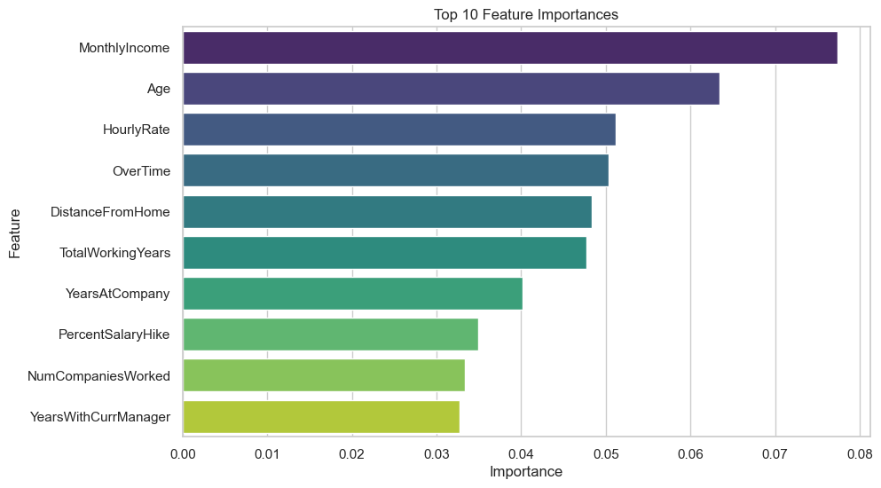

```python
import seaborn as sns
import matplotlib.pyplot as plt

sns.set(style="whitegrid")
feature_importances_df = pd.DataFrame({
    'Feature': best_features_rfi,
    'Importance': feature_importances_rfi
})

plt.figure(figsize=(10, 6))
sns.barplot(
    x='Importance',
    y='Feature',
    data=feature_importances_df,
    palette='viridis'
)
plt.xlabel('Importance')
plt.title('Top 10 Feature Importances')
plt.show()
```

### F-Score Implication

Similar to the Random Forest Importance method, the F-Score operates as a filter-based technique. It assigns an F-Score to each feature, sorted from highest to lowest based on their significance.

```python
# Checking for F-Scores
from sklearn import feature_selection as fs

fit_fscore = fs.SelectKBest(fs.f_classif, k = num_features)
fit_fscore.fit_transform(X_scaled, y)
indices_fscore = np.argsort(np.nan_to_num(fit_fscore.scores_))[::-1][0:num_features]

print(f"Indices are {indices_fscore}")

top_features_fscore = Data_df.columns[indices_fscore].values
top_features_fscore
```

```
Indices are [ 7 56 10  4 13  5  0 49 15 12]
```

```
array(['OverTime', 'MaritalStatus_Single', 'TotalWorkingYears',
       'JobLevel', 'YearsInCurrentRole', 'MonthlyIncome', 'Age',
       'JobRole_Sales Representative', 'YearsWithCurrManager',
       'YearsAtCompany'], dtype=object)
```

```python
# Getting the importances of the features
fscore_importance = fit_fscore.scores_[indices_fscore]
fscore_importance
```

```
array([94.65645707, 46.60698472, 44.25249144, 43.21534383, 38.83830278,
       38.48881898, 38.17588679, 37.21279754, 36.71231147, 27.00162376])
```

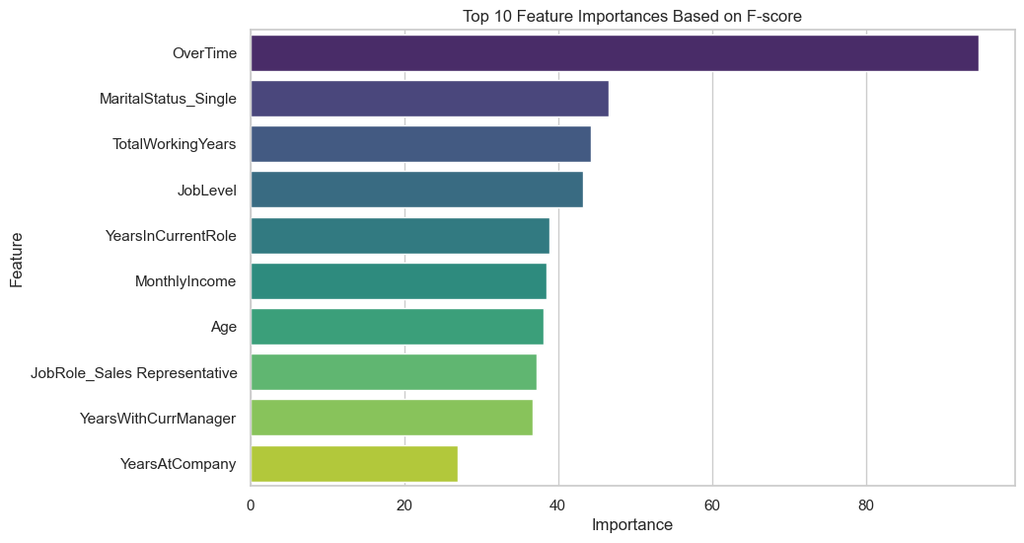

```python
# Plotting the importances
fscore_importances_df = pd.DataFrame({
    'Feature': top_features_fscore,
    'Importance': fscore_importance
})

plt.figure(figsize=(10, 6))
sns.barplot(
    x='Importance',
    y='Feature',
    data=fscore_importances_df,
    palette='viridis'
)
plt.xlabel('Importance')
plt.title('Top 10 Feature Importances Based on F-score')
plt.show()
```

We observe that the most important feature is Overtime, followed by MartialStatus_Single, TotalWorkingYears, and JobLevel

### Model Fitting and Tuning

```python
from sklearn.model_selection import train_test_split
from sklearn.model_selection import StratifiedKFold, GridSearchCV,cross_val_score
from sklearn.tree import DecisionTreeClassifier

X_train, X_test, y_train, y_test = train_test_split(X, y, test_size=0.3, random_state=999,stratify=y)
cv_method=StratifiedKFold(n_splits=5,shuffle=True,random_state=999)
print(X_train.shape)
print(X_test.shape)
```

```
(1029, 65)
(441, 65)
```

Based on the output above, our data has been successfully split into training and testing sets with a ratio of 70% for training and 30% for testing. Now, we can proceed with identifying the optimal hyperparameters for each model.

For hyperparameter tuning, we'll employ 5-fold cross-validation using the StratifiedKFold method. We'll refrain from repeating the process due to limitations of the current computational resources, as additional iterations would significantly increase the number of fits and computational time

## K-Nearest Neighbors

For the K-Nearest Neighbors (KNN) algorithm, we have two key hyperparameters: k (the number of neighbors) and p (the type of distance metric). However, in addition to tuning these hyperparameters, we will also refine the number of features. Similar to our previous approach, where we used Random Forest Importance and F-Score for feature selection, we will incorporate these methods into the fine-tuning process. This will involve integrating Random Forest Importance (or SelectKBest) within a Pipeline, allowing us to select the optimal features alongside tuning hyperparameters.

We will execute these steps using 100 estimators. This approach will also be applied to the following models. As we are dealing with a binary classification problem that exhibits significant class imbalance, we will utilize roc_auc as the scoring metric. Alternatively, we could include class weights as a step in the pipeline to address the imbalance issue

```python
from sklearn.base import BaseEstimator, TransformerMixin
from sklearn.neighbors import KNeighborsClassifier
from sklearn.pipeline import Pipeline
from sklearn.ensemble import RandomForestClassifier
from numpy import argsort

# Creating a class for the Random Forest Classifier
class RFIFeatureSelector(BaseEstimator, TransformerMixin):

    # Defining Constructors of the class
    def __init__(self, n_features_=10):
        self.n_features_ = n_features_
        self.fs_indices_ = None
        self.fs_importance_ = None

    # This overrides the 'fit' function
    def fit(self, X, y):
        model_rfi = RandomForestClassifier(n_estimators=100, random_state=999)
        model_rfi.fit(X, y)
        self.fs_indices_ = argsort(model_rfi.feature_importances_)[::-1][0:self.n_features_]
        self.fs_importance_ = model_rfi.feature_importances_[self.fs_indices_ ]
        return self

    # This overrides the 'transform' function
    def transform(self, X, y=None):
        return X[:, self.fs_indices_]
```

```python
pipe_knn=Pipeline(steps=[('rfi_fs', SelectKBest(score_func=f_classif)),
                   ('knn',KNeighborsClassifier())])
params_knn={'rfi_fs__k':[10,20,X_scaled.shape[1]],
           'knn__n_neighbors':[1,5,10,15,20],
           'knn__p':[1,2]}
gs_pipe_KNN = GridSearchCV(estimator=pipe_knn,
                           param_grid=params_knn,
                           cv=cv_method,
                           refit=True,
                           n_jobs=-2,
                           scoring='roc_auc',
                           verbose=1)
```

```python
gs_pipe_KNN.fit(X_train, y_train)
```

```
Fitting 5 folds for each of 30 candidates, totalling 150 fits
```

```
GridSearchCV(cv=StratifiedKFold(n_splits=5, random_state=999, shuffle=True),
             estimator=Pipeline(steps=[('rfi_fs', SelectKBest()),
                                       ('knn', KNeighborsClassifier())]),
             n_jobs=-2,
             param_grid={'knn__n_neighbors': [1, 5, 10, 15, 20],
                         'knn__p': [1, 2], 'rfi_fs__k': [10, 20, 65]},
             scoring='roc_auc', verbose=1)
```

```python
gs_pipe_KNN.best_params_
```

```
{'knn__n_neighbors': 10, 'knn__p': 1, 'rfi_fs__k': 65}
```

```python
gs_pipe_KNN.best_score_
```

```
0.6669711125232701
```

```python
# Predicting the outcome
from sklearn import metrics
pred_KNN = gs_pipe_KNN.predict(X_test)
print(f'ROC_AUC score via KNN {metrics.roc_auc_score(y_test,pred_KNN)}')
```

```
ROC_AUC score via KNN 0.5029881994670727
```

From the outputs above, we can infer that the optimal KNN model has a mean `roc_auc` score of 0.66 approximately for 10 nearest neighbors, using the Manhattan Distance `p=1`, and 65 as the best number of features.

As a good measure of statistic, we will also check other combinations of results via the following function.

```python
def get_search_results(gs):

    def model_result(scores, params):
        scores = {'mean_score': np.mean(scores),
             'std_score': np.std(scores),
             'min_score': np.min(scores),
             'max_score': np.max(scores)}
        return pd.Series({**params,**scores})

    models = []
    scores = []

    for i in range(gs.n_splits_):
        key = f"split{i}_test_score"
        r = gs.cv_results_[key]
        scores.append(r.reshape(-1,1))

    all_scores = np.hstack(scores)
    for p, s in zip(gs.cv_results_['params'], all_scores):
        models.append((model_result(s, p)))

    pipe_results = pd.concat(models, axis=1).T.sort_values(['mean_score'], ascending=False)

    columns_first = ['mean_score', 'std_score', 'max_score', 'min_score']
    columns = columns_first + [c for c in pipe_results.columns if c not in columns_first]

    return pipe_results[columns]
```

```python
results_KNN = get_search_results(gs_pipe_KNN)
results_KNN.head()
```

|  | mean_score | std_score | max_score | min_score | knn__n_neighbors | knn__p | rfi_fs__k |
| --- | --- | --- | --- | --- | --- | --- | --- |
| 14 | 0.666971 | 0.029374 | 0.716238 | 0.635174 | 10.0 | 1.0 | 65.0 |
| 20 | 0.658963 | 0.034195 | 0.704852 | 0.619010 | 15.0 | 1.0 | 65.0 |
| 17 | 0.654541 | 0.035723 | 0.704502 | 0.603608 | 10.0 | 2.0 | 65.0 |
| 19 | 0.651436 | 0.039346 | 0.698984 | 0.590997 | 15.0 | 1.0 | 20.0 |
| 22 | 0.649476 | 0.031944 | 0.690927 | 0.594873 | 15.0 | 2.0 | 20.0 |

```python
results_KNN_10_features = results_KNN[results_KNN['rfi_fs__k'] == 10.0]
```

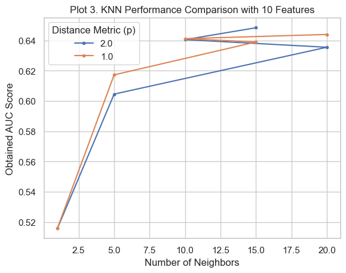

```python
for i in results_KNN_10_features['knn__p'].unique():
    temp = results_KNN_10_features[results_KNN_10_features['knn__p'] == i]
    plt.plot(temp['knn__n_neighbors'], temp['mean_score'], marker = '.', label = i)

plt.legend(title = "Distance Metric (p)")
plt.xlabel('Number of Neighbors')
plt.ylabel("Obtained AUC Score")
plt.title("Plot 3. KNN Performance Comparison with 10 Features")
plt.show()
```

After fitting the GridSearchCV, the results are extracted and organized into a DataFrame for analysis.

The focus is on examining the top 10 features selected by the RFI feature selection method and plotting the mean AUC scores for different KNN hyperparameters. The resulting plots illustrate the performance of the KNN classifier with varying numbers of neighbors and distance metrics, providing insights into the best configurations for the given dataset.

## Decision Tree

We build a DT using gini index to maximize information gain. Our goal is to identify the optimal combinations of maximum depth (max_depth) and minimum sample split (min_samples_split).

```python
from sklearn.model_selection import GridSearchCV
from sklearn.tree import DecisionTreeClassifier
from sklearn.feature_selection import SelectKBest, f_classif

pipe_dt = Pipeline([
    ('rfi_fs', SelectKBest(score_func=f_classif)),
    ('dt', DecisionTreeClassifier(criterion='gini', random_state=999))
])

param_dt = {
    'rfi_fs__k': [10, 20, X_scaled.shape[1]],
    'dt__max_depth': [3, 5, 7,9],
    'dt__min_samples_split': [2, 5,16]
}

gs_pipe_dt = GridSearchCV(pipe_dt, param_grid=param_dt, n_jobs=1, cv=cv_method,
                          refit=True, scoring='roc_auc', verbose=1)

gs_pipe_dt.fit(X_train, y_train)
```

```
Fitting 5 folds for each of 36 candidates, totalling 180 fits
```

```
GridSearchCV(cv=StratifiedKFold(n_splits=5, random_state=999, shuffle=True),
             estimator=Pipeline(steps=[('rfi_fs', SelectKBest()),
                                       ('dt',
                                        DecisionTreeClassifier(random_state=999))]),
             n_jobs=1,
             param_grid={'dt__max_depth': [3, 5, 7, 9],
                         'dt__min_samples_split': [2, 5, 16],
                         'rfi_fs__k': [10, 20, 65]},
             scoring='roc_auc', verbose=1)
```

```python
gs_pipe_dt.best_params_
```

```
{'dt__max_depth': 5, 'dt__min_samples_split': 16, 'rfi_fs__k': 20}
```

```python
gs_pipe_dt.best_score_
```

```
0.7455040419056573
```

```python
# Calculating for Decision Tree
pred_DT = gs_pipe_dt.predict(X_test)
print(f'ROC_AUC score via DT {metrics.roc_auc_score(y_test,pred_DT)}')
```

```
ROC_AUC score via DT 0.5739817282070803
```

The Decision Tree Classifier yielded a mean roc_auc of approximately 0.745, utilizing the optimal parameters: max_depth=5, min_samples_split=16, and employing 20 features.

To evaluate the significance of this result compared to other top values, we'll utilize the custom function get_search_results().

After fitting the GridSearchCV to the training data, a custom function is used to extract and compile the search results. This function processes the cross-validation results, calculating mean, standard deviation, minimum, and maximum scores for each parameter combination, and organizing them into a DataFrame for easy analysis

```python
results_dt = get_search_results(gs_pipe_dt)
results_dt.head()
```

|  | mean_score | std_score | max_score | min_score | dt__max_depth | dt__min_samples_split | rfi_fs__k |
| --- | --- | --- | --- | --- | --- | --- | --- |
| 16 | 0.745504 | 0.049554 | 0.805395 | 0.675337 | 5.0 | 16.0 | 20.0 |
| 25 | 0.736512 | 0.048803 | 0.807059 | 0.667367 | 7.0 | 16.0 | 20.0 |
| 34 | 0.727380 | 0.047038 | 0.799439 | 0.685409 | 9.0 | 16.0 | 20.0 |
| 13 | 0.721893 | 0.059884 | 0.802330 | 0.628569 | 5.0 | 5.0 | 20.0 |
| 2 | 0.711905 | 0.036081 | 0.765195 | 0.681025 | 3.0 | 2.0 | 65.0 |

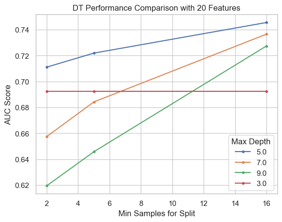

```python
results_DT = get_search_results(gs_pipe_dt)
results_DT_10_features = results_DT[results_DT['rfi_fs__k'] == 20]


for i in results_DT_10_features['dt__max_depth'].unique():
    temp = results_DT_10_features[results_DT_10_features['dt__max_depth'] == i]
    plt.plot(temp['dt__min_samples_split'], temp['mean_score'], marker = '.', label = i)

plt.legend(title = "Max Depth")
plt.xlabel('Min Samples for Split')
plt.ylabel("AUC Score")
plt.title("DT Performance Comparison with 20 Features")
plt.show()
```

Moreover, the plot for max_depth=7 and 9 demonstrates a consistent increase in performance with an increasing number of splits, suggesting that a slightly higher min_samples_split may lead to a marginally better mean roc_auc score.

## Random forest

```python
from sklearn.ensemble import RandomForestClassifier
rf=RandomForestClassifier(n_estimators=5)
rf.fit(X_train, y_train)
rf.score(X_test, y_test)
```

```
0.8253968253968254
```

```python
from sklearn.pipeline import Pipeline
from sklearn.model_selection import GridSearchCV
from sklearn.ensemble import RandomForestClassifier
from sklearn.feature_selection import SelectKBest, f_classif

clf = RandomForestClassifier(random_state=42)

pipe_rf = Pipeline([
    ('rfi_fs', SelectKBest(score_func=f_classif)),
    ('rf', clf)
])

# Define the parameter grid
param_rf = {
    'rfi_fs__k': [5, 50, X_scaled.shape[1]],
    'rf__n_estimators': [1,50, 100],
    'rf__max_depth': [1,5, 10],
    'rf__min_samples_split': [2, 5]
}

# Create the GridSearchCV object
gs_pipe_rf = GridSearchCV(pipe_rf, param_grid=param_rf, n_jobs=1, cv=cv_method,
                          refit=True, scoring='roc_auc', verbose=1)

# Fit the GridSearchCV object
gs_pipe_rf.fit(X_train, y_train)
```

```
Fitting 5 folds for each of 54 candidates, totalling 270 fits
```

```
GridSearchCV(cv=StratifiedKFold(n_splits=5, random_state=999, shuffle=True),
             estimator=Pipeline(steps=[('rfi_fs', SelectKBest()),
                                       ('rf',
                                        RandomForestClassifier(random_state=42))]),
             n_jobs=1,
             param_grid={'rf__max_depth': [1, 5, 10],
                         'rf__min_samples_split': [2, 5],
                         'rf__n_estimators': [1, 50, 100],
                         'rfi_fs__k': [5, 50, 65]},
             scoring='roc_auc', verbose=1)
```

```python
gs_pipe_rf.best_params_
```

```
{'rf__max_depth': 10,
 'rf__min_samples_split': 5,
 'rf__n_estimators': 100,
 'rfi_fs__k': 50}
```

```python
gs_pipe_rf.best_score_
```

```
0.8103019172693703
```

```python
# Calculating for Logistic Regressor
pred_RF = gs_pipe_rf.predict(X_test)
print(f'ROC_AUC score via LR {metrics.roc_auc_score(y_test,pred_RF)}')
```

```
ROC_AUC score via LR 0.5549866768176628
```

To evaluate the significance of this result compared to other top values, we'll utilize the custom function get_search_results().

```python
results_rf = get_search_results(gs_pipe_rf)
results_rf.head()
```

|  | mean_score | std_score | max_score | min_score | rf__max_depth | rf__min_samples_split | rf__n_estimators | rfi_fs__k |
| --- | --- | --- | --- | --- | --- | --- | --- | --- |
| 52 | 0.810302 | 0.033372 | 0.860396 | 0.762141 | 10.0 | 5.0 | 100.0 | 50.0 |
| 53 | 0.809596 | 0.025652 | 0.842004 | 0.765903 | 10.0 | 5.0 | 100.0 | 65.0 |
| 25 | 0.806075 | 0.033571 | 0.850937 | 0.765856 | 5.0 | 2.0 | 100.0 | 50.0 |
| 31 | 0.805329 | 0.031945 | 0.856192 | 0.765152 | 5.0 | 5.0 | 50.0 | 50.0 |
| 43 | 0.805329 | 0.021045 | 0.836224 | 0.771846 | 10.0 | 2.0 | 100.0 | 50.0 |

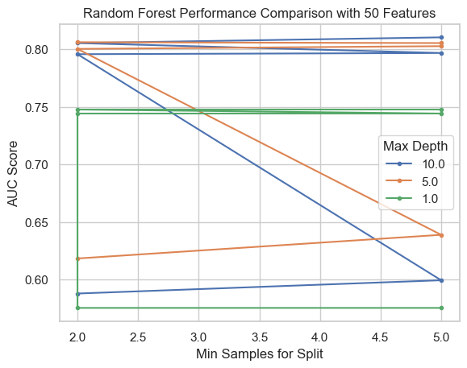

```python
results_rf = get_search_results(gs_pipe_rf)
results_rf_20_features = results_rf[results_rf['rfi_fs__k'] == 50]

for i in results_rf_20_features['rf__max_depth'].unique():
    temp = results_rf_20_features[results_rf_20_features['rf__max_depth'] == i]
    plt.plot(temp['rf__min_samples_split'], temp['mean_score'], marker='.', label=i)

plt.legend(title="Max Depth")
plt.xlabel('Min Samples for Split')
plt.ylabel("AUC Score")
plt.title("Random Forest Performance Comparison with 50 Features")
plt.show()
```

## Naive Bayes

To meet the assumption of the Naive Bayes Algorithm, which necessitates features to follow a normal distribution (a condition often not met in practice), we employ a power transformer. This transformation is applied to the input data before fitting the model, ensuring that the distribution of features adheres more closely to the normal distribution assumption required by the algorithm

```python
from sklearn.preprocessing import PowerTransformer
X_train_transformed = PowerTransformer().fit_transform(X_train)
```

```python
from sklearn.pipeline import Pipeline
from sklearn.feature_selection import SelectKBest
from sklearn.naive_bayes import GaussianNB
from sklearn.model_selection import GridSearchCV
from sklearn.feature_selection import f_classif
import numpy as np

# Assuming you have the necessary data and preprocessing done
# X_train, X_test, y_train, y_test

# Create the pipeline
pipe_NB = Pipeline([
    ('rfi_fs', SelectKBest(score_func=f_classif)),
    ('nb', GaussianNB())
])

# Define the parameters for grid search
params_pipe_NB = {
    'rfi_fs__k': [10, 20, 30],  # Number of features to select
    'nb__var_smoothing': np.logspace(1, -3, num=80)  # Smoothing parameter
}

# Initialize GridSearchCV
gs_pipe_NB = GridSearchCV(
    estimator=pipe_NB,
    param_grid=params_pipe_NB,
    cv=cv_method,
    refit=True,
    n_jobs=-2,
    scoring='roc_auc',
    verbose=1
)

# Fit the pipeline
gs_pipe_NB.fit(X_train_transformed, y_train)
```

```
Fitting 5 folds for each of 240 candidates, totalling 1200 fits
```

```
GridSearchCV(cv=StratifiedKFold(n_splits=5, random_state=999, shuffle=True),
             estimator=Pipeline(steps=[('rfi_fs', SelectKBest()),
                                       ('nb', GaussianNB())]),
             n_jobs=-2,
             param_grid={'nb__var_smoothing': array([1.00000000e+01, 8.89953035e+00, 7.92016405e+00, 7.04857404e+00,
       6.27289986e+00, 5.58258627e+00, 4.96823959e+00, 4.42149991e+00,
       3.93492726e+00, 3.50190046e+00, 3.11...
       9.16273901e-03, 8.15440740e-03, 7.25703961e-03, 6.45842443e-03,
       5.74769442e-03, 5.11517810e-03, 4.55226828e-03, 4.05130497e-03,
       3.60547115e-03, 3.20870000e-03, 2.85559230e-03, 2.54134304e-03,
       2.26167595e-03, 2.01278538e-03, 1.79128445e-03, 1.59415904e-03,
       1.41872667e-03, 1.26260011e-03, 1.12365480e-03, 1.00000000e-03]),
                         'rfi_fs__k': [10, 20, 30]},
             scoring='roc_auc', verbose=1)
```

```python
gs_pipe_NB.best_params_
```

```
{'nb__var_smoothing': 8.899530352885229, 'rfi_fs__k': 30}
```

```python
gs_pipe_NB.best_score_
```

```
0.7854727182151013
```

```python
# Calculating for Naive Bayes
pred_NB = gs_pipe_NB.predict(X_test)
print(f'ROC_AUC score via NB {metrics.roc_auc_score(y_test,pred_NB)}')
```

```
ROC_AUC score via NB 0.5
```

The optimal Naive Bayes Algorithm yields a `roc_auc` score of 0.785 approximately. Which is 2nd highest as compared to other alogorithms. Like we performed for the algorithms above, we will check the other top - 4 values as well.

```python
# Retrieving the other top-4 values
results_NB = get_search_results(gs_pipe_NB)
results_NB.head()
```

|  | mean_score | std_score | max_score | min_score | nb__var_smoothing | rfi_fs__k |
| --- | --- | --- | --- | --- | --- | --- |
| 5 | 0.785473 | 0.033560 | 0.842529 | 0.738714 | 8.899530 | 30.0 |
| 8 | 0.785331 | 0.033360 | 0.842004 | 0.738885 | 7.920164 | 30.0 |
| 2 | 0.785159 | 0.033783 | 0.842880 | 0.738201 | 10.000000 | 30.0 |
| 17 | 0.784880 | 0.033564 | 0.840953 | 0.738201 | 5.582586 | 30.0 |
| 14 | 0.784810 | 0.033712 | 0.841654 | 0.738372 | 6.272900 | 30.0 |

Similar to the other algorithms, we observe minimal variation in the mean_score values across the top-30 features. Let's proceed to visualize the results.

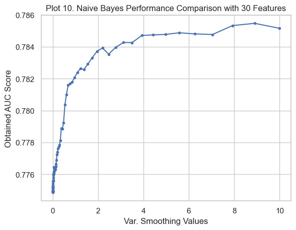

```python
results_NB_30_features = results_NB[results_NB['rfi_fs__k'] == 30.0].sort_values('nb__var_smoothing')

plt.plot(results_NB_30_features['nb__var_smoothing'], results_NB_30_features['mean_score'], marker = '.', label = i)
plt.xlabel('Var. Smoothing Values')
plt.ylabel("Obtained AUC Score")
plt.title("Plot 10. Naive Bayes Performance Comparison with 30 Features")
plt.show()
```

## Logistic Regression model

While this algorithm doesn't have critical hyperparameters to tune, variations in performance can arise from different solvers. Regularization plays a vital role, achieved through penalty usage. However, not all penalties are supported by all solvers. Since 'l2' is the most common, it will be the focus of our tuning efforts.

```python
Data_LR = X_scaled.copy()
```

```python
from sklearn.linear_model import LogisticRegression
X_train, X_test, y_train, y_test = train_test_split(Data_LR, y, test_size=0.2, random_state=42)
pipe_LR = Pipeline(steps=[
    ('rfi_fs', RFIFeatureSelector()),
    ('LR', LogisticRegression())
])

params_pipe_LR = {
    'rfi_fs__n_features_': [10, 20, 30],
    'LR__C': [0.001, 0.01, 0.1, 1, 10, 100],
    'LR__penalty': ['l2'],
    'LR__solver': ['newton-cg', 'lbfgs', 'liblinear', 'saga']
}

gs_pipe_LR = GridSearchCV(estimator=pipe_LR,
                           param_grid=params_pipe_LR,
                           cv=cv_method,
                           refit=True,
                           n_jobs=-2,
                           scoring='roc_auc',
                           verbose=1)
```

```python
#  5-fold cross-validation
# Fetching the best parameters

gs_pipe_LR.fit(X_train, y_train)
```

```
Fitting 5 folds for each of 72 candidates, totalling 360 fits
```

```
GridSearchCV(cv=StratifiedKFold(n_splits=5, random_state=999, shuffle=True),
             estimator=Pipeline(steps=[('rfi_fs', RFIFeatureSelector()),
                                       ('LR', LogisticRegression())]),
             n_jobs=-2,
             param_grid={'LR__C': [0.001, 0.01, 0.1, 1, 10, 100],
                         'LR__penalty': ['l2'],
                         'LR__solver': ['newton-cg', 'lbfgs', 'liblinear',
                                        'saga'],
                         'rfi_fs__n_features_': [10, 20, 30]},
             scoring='roc_auc', verbose=1)
```

```python
gs_pipe_LR.best_params_
```

```
{'LR__C': 1,
 'LR__penalty': 'l2',
 'LR__solver': 'newton-cg',
 'rfi_fs__n_features_': 30}
```

```python
# Fetching the best score
gs_pipe_LR.best_score_
```

```
0.8406284667713239
```

```python
# Calculating for Logistic Regressor
pred_LR = gs_pipe_LR.predict(X_test)
print(f'ROC_AUC score via LR {metrics.roc_auc_score(y_test,pred_LR)}')
```

```
ROC_AUC score via LR 0.589894419306184
```

```python
results_LR = get_search_results(gs_pipe_LR)
results_LR.head()
```

|  | mean_score | std_score | max_score | min_score | LR__C | LR__penalty | LR__solver | rfi_fs__n_features_ |
| --- | --- | --- | --- | --- | --- | --- | --- | --- |
| 41 | 0.840628 | 0.02308 | 0.865385 | 0.797959 | 1 | l2 | lbfgs | 30 |
| 38 | 0.840628 | 0.02308 | 0.865385 | 0.797959 | 1 | l2 | newton-cg | 30 |
| 47 | 0.840577 | 0.023174 | 0.865385 | 0.797704 | 1 | l2 | saga | 30 |
| 50 | 0.840577 | 0.019482 | 0.864076 | 0.805102 | 10 | l2 | newton-cg | 30 |
| 59 | 0.840576 | 0.019442 | 0.863946 | 0.805102 | 10 | l2 | saga | 30 |

[figure not shown]

```python
results_LR_30_features = results_LR[results_LR['rfi_fs__n_features_'] == 20.0].sort_values('LR__C')

# For loop to iterate over the different 'max_depth' values
for i in results_LR_30_features['LR__solver'].unique():
    temp = results_LR_30_features[results_LR_30_features['LR__solver'] == i]
    plt.plot(temp['LR__C'], temp['mean_score'], marker = '.', label = i)

plt.legend(title = "Solvers")
plt.xlabel('Values of C')
plt.ylabel("Obtained AUC Score")
plt.title("Plot 12. Logistic Regression Classifier Performance Comparison with 30 Features")
plt.show()
```

We can clearly observe the elbow-shape on the curves, which depicts the constant performance after having reached the maximum performance at the value of C = 1.0

# Neural Network Model Fitting & Tuning

## Tash 2.2.5

#### Introduction

The aim of this part is to use Neural Networks for a binary classification. These models are inspired from human brains and work in a similar way to caputre intricate patterns in the data.

- Model overview

We have used a sequential model using TensorFlow Keras, which is designed with multiple layers to ensure effective learning from the training data. The input data has been classified into two categories.

#### Model parameters

- The activation functions used are ReLu and Sigmoid, to inrtoduce non linearity and to map prediction to probablities.
- Batch normalisation applied after eah denser layer to standardise the inputs to the subsequent layers.
- Dropout rates are 0.4 after the input layer, 0.5 after the 1st and 2nd hidden layers.
- For optimizer used a learning rate of 0.001Used Adam optimizer.
- binary Crossentropy which is suitable for binary classifications is used as a loss function.
- Accuracy is used to compare model's performance after comparing the predicated labels with the true lables.

```python
data_NN = X_scaled.copy()
```

```python
# Import necessary libraries
import numpy as np
import pandas as pd
from sklearn.model_selection import train_test_split
from tensorflow.keras.models import Sequential
from tensorflow.keras.layers import Dense, Dropout, BatchNormalization
from tensorflow.keras.optimizers import Adam
import matplotlib.pyplot as plt

X_train, X_test, y_train, y_test = train_test_split(data_NN, y, test_size=0.2, random_state=42)

# Define a function to create the model with configurable hyperparameters
def create_model(learning_rate=0.001, dropout_rate=0.5, num_neurons=128):
    model = Sequential()
    # Input layer and first hidden layer
    model.add(Dense(num_neurons, input_shape=(X_train.shape[1],), activation='relu'))
    model.add(BatchNormalization())
    model.add(Dropout(0.4))

    # First hidden layer
    model.add(Dense(64, activation='relu'))
    model.add(BatchNormalization())
    model.add(Dropout(dropout_rate))

    # Second hidden layer
    model.add(Dense(32, activation='relu'))
    model.add(BatchNormalization())
    model.add(Dropout(dropout_rate))

    # Output layer
    model.add(Dense(1, activation='sigmoid'))

    # Compile the model
    model.compile(optimizer=Adam(learning_rate=learning_rate), loss='binary_crossentropy', metrics=['accuracy'])
    return model
```

#### Fine tuningHyperparameters plots

- 1st plot.

We set the learning rates to 0.0001,0.001,0.01,0.1

[output not shown]

[output cut: 145 more lines]

[output not shown]

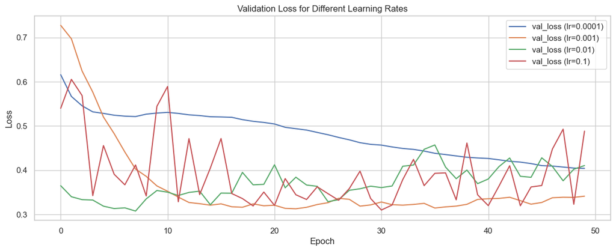

```python
learning_rates = [0.0001, 0.001, 0.01, 0.1]
histories = {}

for lr in learning_rates:
    model = create_model(learning_rate=lr)
    history = model.fit(X_train, y_train, epochs=50, batch_size=32, validation_data=(X_test, y_test))
    histories[lr] = history

plt.figure(figsize=(14, 5))
for lr, history in histories.items():
    plt.plot(history.history['val_loss'], label=f'val_loss (lr={lr})')
plt.title('Validation Loss for Different Learning Rates')
plt.ylabel('Loss')
plt.xlabel('Epoch')
plt.legend(loc='upper right')
plt.show()
```

In the graph above we can ovebserve the $0.001$ allowed the model to converge effeciently. This is the most optimal choice of the learning rate.

- 2nd Plot

Here we keep the dropout rate 0.3, 0.4, 0.5, and 0.6.

[output not shown]

[output cut: 145 more lines]

[output not shown]

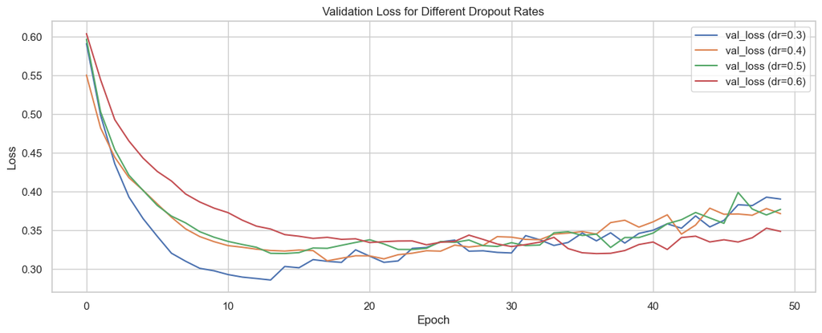

```python
dropout_rates = [0.3, 0.4, 0.5, 0.6]
histories = {}

for dr in dropout_rates:
    model = create_model(dropout_rate=dr)
    history = model.fit(X_train, y_train, epochs=50, batch_size=32, validation_data=(X_test, y_test))
    histories[dr] = history

plt.figure(figsize=(14, 5))
for dr, history in histories.items():
    plt.plot(history.history['val_loss'], label=f'val_loss (dr={dr})')
plt.title('Validation Loss for Different Dropout Rates')
plt.ylabel('Loss')
plt.xlabel('Epoch')
plt.legend(loc='upper right')
plt.show()
```

We can oberve that $0.5$ provides a decent trade off, avoiding overfitting.

- 3rd Plot

We change the batch size to 16, 32,64, 128.

```
74/74 ━━━━━━━━━━━━━━━━━━━━ 2s 5ms/step - accuracy: 0.5358 - loss: 0.8909 - val_accuracy: 0.8741 - val_loss: 0.5574
74/74 ━━━━━━━━━━━━━━━━━━━━ 0s 2ms/step - accuracy: 0.6160 - loss: 0.7338 - val_accuracy: 0.8673 - val_loss: 0.4627
74/74 ━━━━━━━━━━━━━━━━━━━━ 0s 2ms/step - accuracy: 0.6825 - loss: 0.6436 - val_accuracy: 0.8707 - val_loss: 0.4101
74/74 ━━━━━━━━━━━━━━━━━━━━ 0s 2ms/step - accuracy: 0.7285 - loss: 0.5407 - val_accuracy: 0.8707 - val_loss: 0.3871
74/74 ━━━━━━━━━━━━━━━━━━━━ 0s 2ms/step - accuracy: 0.7600 - loss: 0.5329 - val_accuracy: 0.8707 - val_loss: 0.3813
74/74 ━━━━━━━━━━━━━━━━━━━━ 0s 2ms/step - accuracy: 0.7822 - loss: 0.4799 - val_accuracy: 0.8673 - val_loss: 0.3662
74/74 ━━━━━━━━━━━━━━━━━━━━ 0s 2ms/step - accuracy: 0.8138 - loss: 0.4505 - val_accuracy: 0.8707 - val_loss: 0.3491
74/74 ━━━━━━━━━━━━━━━━━━━━ 0s 2ms/step - accuracy: 0.8183 - loss: 0.4243 - val_accuracy: 0.8605 - val_loss: 0.3469
74/74 ━━━━━━━━━━━━━━━━━━━━ 0s 3ms/step - accuracy: 0.8319 - loss: 0.4154 - val_accuracy: 0.8639 - val_loss: 0.3381
74/74 ━━━━━━━━━━━━━━━━━━━━ 0s 2ms/step - accuracy: 0.8392 - loss: 0.3988 - val_accuracy: 0.8844 - val_loss: 0.3291
74/74 ━━━━━━━━━━━━━━━━━━━━ 0s 2ms/step - accuracy: 0.8466 - loss: 0.3941 - val_accuracy: 0.8776 - val_loss: 0.3331
74/74 ━━━━━━━━━━━━━━━━━━━━ 0s 2ms/step - accuracy: 0.8444 - loss: 0.3901 - val_accuracy: 0.8707 - val_loss: 0.3383
74/74 ━━━━━━━━━━━━━━━━━━━━ 0s 2ms/step - accuracy: 0.8280 - loss: 0.3932 - val_accuracy: 0.8810 - val_loss: 0.3287
74/74 ━━━━━━━━━━━━━━━━━━━━ 0s 2ms/step - accuracy: 0.8423 - loss: 0.3566 - val_accuracy: 0.8776 - val_loss: 0.3310
74/74 ━━━━━━━━━━━━━━━━━━━━ 0s 2ms/step - accuracy: 0.8527 - loss: 0.3925 - val_accuracy: 0.8776 - val_loss: 0.3312
74/74 ━━━━━━━━━━━━━━━━━━━━ 0s 3ms/step - accuracy: 0.8539 - loss: 0.3647 - val_accuracy: 0.8810 - val_loss: 0.3279
74/74 ━━━━━━━━━━━━━━━━━━━━ 0s 3ms/step - accuracy: 0.8684 - loss: 0.3326 - val_accuracy: 0.8844 - val_loss: 0.3342
74/74 ━━━━━━━━━━━━━━━━━━━━ 0s 2ms/step - accuracy: 0.8566 - loss: 0.3410 - val_accuracy: 0.8844 - val_loss: 0.3229
74/74 ━━━━━━━━━━━━━━━━━━━━ 0s 2ms/step - accuracy: 0.8859 - loss: 0.3061 - val_accuracy: 0.8844 - val_loss: 0.3203
74/74 ━━━━━━━━━━━━━━━━━━━━ 0s 3ms/step - accuracy: 0.8702 - loss: 0.3209 - val_accuracy: 0.8707 - val_loss: 0.3239
74/74 ━━━━━━━━━━━━━━━━━━━━ 0s 3ms/step - accuracy: 0.8673 - loss: 0.3269 - val_accuracy: 0.8776 - val_loss: 0.3216
74/74 ━━━━━━━━━━━━━━━━━━━━ 0s 3ms/step - accuracy: 0.8734 - loss: 0.3053 - val_accuracy: 0.8639 - val_loss: 0.3269
74/74 ━━━━━━━━━━━━━━━━━━━━ 0s 2ms/step - accuracy: 0.8519 - loss: 0.3308 - val_accuracy: 0.8639 - val_loss: 0.3239
74/74 ━━━━━━━━━━━━━━━━━━━━ 0s 2ms/step - accuracy: 0.8760 - loss: 0.2993 - val_accuracy: 0.8639 - val_loss: 0.3265
74/74 ━━━━━━━━━━━━━━━━━━━━ 0s 3ms/step - accuracy: 0.8711 - loss: 0.3163 - val_accuracy: 0.8605 - val_loss: 0.3276
74/74 ━━━━━━━━━━━━━━━━━━━━ 0s 3ms/step - accuracy: 0.8816 - loss: 0.2864 - val_accuracy: 0.8673 - val_loss: 0.3172
74/74 ━━━━━━━━━━━━━━━━━━━━ 0s 2ms/step - accuracy: 0.8684 - loss: 0.3242 - val_accuracy: 0.8707 - val_loss: 0.3110
74/74 ━━━━━━━━━━━━━━━━━━━━ 0s 2ms/step - accuracy: 0.8897 - loss: 0.2804 - val_accuracy: 0.8673 - val_loss: 0.3184
74/74 ━━━━━━━━━━━━━━━━━━━━ 0s 2ms/step - accuracy: 0.8876 - loss: 0.2893 - val_accuracy: 0.8810 - val_loss: 0.3112
74/74 ━━━━━━━━━━━━━━━━━━━━ 0s 2ms/step - accuracy: 0.8968 - loss: 0.2874 - val_accuracy: 0.8810 - val_loss: 0.3089
74/74 ━━━━━━━━━━━━━━━━━━━━ 0s 4ms/step - accuracy: 0.8928 - loss: 0.2677 - val_accuracy: 0.8741 - val_loss: 0.3115
74/74 ━━━━━━━━━━━━━━━━━━━━ 0s 3ms/step - accuracy: 0.8885 - loss: 0.2563 - val_accuracy: 0.8741 - val_loss: 0.3150
74/74 ━━━━━━━━━━━━━━━━━━━━ 0s 3ms/step - accuracy: 0.8760 - loss: 0.3214 - val_accuracy: 0.8707 - val_loss: 0.3222
74/74 ━━━━━━━━━━━━━━━━━━━━ 0s 2ms/step - accuracy: 0.8648 - loss: 0.3004 - val_accuracy: 0.8673 - val_loss: 0.3081
74/74 ━━━━━━━━━━━━━━━━━━━━ 0s 2ms/step - accuracy: 0.8794 - loss: 0.3017 - val_accuracy: 0.8673 - val_loss: 0.3230
74/74 ━━━━━━━━━━━━━━━━━━━━ 0s 2ms/step - accuracy: 0.8787 - loss: 0.2727 - val_accuracy: 0.8673 - val_loss: 0.3094
74/74 ━━━━━━━━━━━━━━━━━━━━ 0s 3ms/step - accuracy: 0.8945 - loss: 0.2505 - val_accuracy: 0.8810 - val_loss: 0.3161
74/74 ━━━━━━━━━━━━━━━━━━━━ 0s 2ms/step - accuracy: 0.8894 - loss: 0.2716 - val_accuracy: 0.8776 - val_loss: 0.3332
74/74 ━━━━━━━━━━━━━━━━━━━━ 0s 2ms/step - accuracy: 0.9079 - loss: 0.2440 - val_accuracy: 0.8776 - val_loss: 0.3492
74/74 ━━━━━━━━━━━━━━━━━━━━ 0s 2ms/step - accuracy: 0.9008 - loss: 0.2318 - val_accuracy: 0.8844 - val_loss: 0.3328
```

[output cut: 145 more lines]

```
10/10 ━━━━━━━━━━━━━━━━━━━━ 0s 5ms/step - accuracy: 0.8775 - loss: 0.3487 - val_accuracy: 0.8844 - val_loss: 0.3142
10/10 ━━━━━━━━━━━━━━━━━━━━ 0s 5ms/step - accuracy: 0.8556 - loss: 0.3531 - val_accuracy: 0.8810 - val_loss: 0.3134
10/10 ━━━━━━━━━━━━━━━━━━━━ 0s 5ms/step - accuracy: 0.8591 - loss: 0.3466 - val_accuracy: 0.8810 - val_loss: 0.3116
10/10 ━━━━━━━━━━━━━━━━━━━━ 0s 6ms/step - accuracy: 0.8700 - loss: 0.3598 - val_accuracy: 0.8741 - val_loss: 0.3119
10/10 ━━━━━━━━━━━━━━━━━━━━ 0s 7ms/step - accuracy: 0.8663 - loss: 0.3327 - val_accuracy: 0.8741 - val_loss: 0.3110
10/10 ━━━━━━━━━━━━━━━━━━━━ 0s 5ms/step - accuracy: 0.8787 - loss: 0.3249 - val_accuracy: 0.8776 - val_loss: 0.3108
10/10 ━━━━━━━━━━━━━━━━━━━━ 0s 6ms/step - accuracy: 0.8893 - loss: 0.3107 - val_accuracy: 0.8776 - val_loss: 0.3088
10/10 ━━━━━━━━━━━━━━━━━━━━ 0s 5ms/step - accuracy: 0.8807 - loss: 0.3133 - val_accuracy: 0.8741 - val_loss: 0.3075
10/10 ━━━━━━━━━━━━━━━━━━━━ 0s 5ms/step - accuracy: 0.8826 - loss: 0.3040 - val_accuracy: 0.8776 - val_loss: 0.3070
10/10 ━━━━━━━━━━━━━━━━━━━━ 0s 5ms/step - accuracy: 0.8831 - loss: 0.3135 - val_accuracy: 0.8844 - val_loss: 0.3078
10/10 ━━━━━━━━━━━━━━━━━━━━ 0s 5ms/step - accuracy: 0.8733 - loss: 0.3207 - val_accuracy: 0.8810 - val_loss: 0.3094
10/10 ━━━━━━━━━━━━━━━━━━━━ 0s 5ms/step - accuracy: 0.8805 - loss: 0.3118 - val_accuracy: 0.8810 - val_loss: 0.3097
10/10 ━━━━━━━━━━━━━━━━━━━━ 0s 5ms/step - accuracy: 0.8851 - loss: 0.2932 - val_accuracy: 0.8810 - val_loss: 0.3090
10/10 ━━━━━━━━━━━━━━━━━━━━ 0s 5ms/step - accuracy: 0.8893 - loss: 0.3073 - val_accuracy: 0.8707 - val_loss: 0.3098
10/10 ━━━━━━━━━━━━━━━━━━━━ 0s 7ms/step - accuracy: 0.9128 - loss: 0.2669 - val_accuracy: 0.8741 - val_loss: 0.3097
```

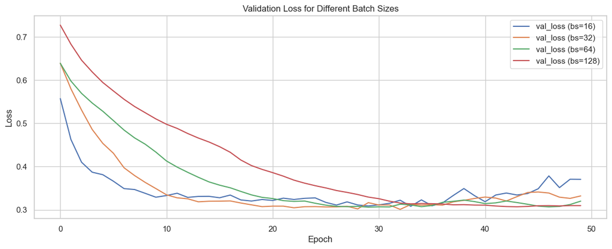

```python
batch_sizes = [16, 32, 64, 128]
histories = {}

for bs in batch_sizes:
    model = create_model()
    history = model.fit(X_train, y_train, epochs=50, batch_size=bs, validation_data=(X_test, y_test))
    histories[bs] = history

plt.figure(figsize=(14, 5))
for bs, history in histories.items():
    plt.plot(history.history['val_loss'], label=f'val_loss (bs={bs})')
plt.title('Validation Loss for Different Batch Sizes')
plt.ylabel('Loss')
plt.xlabel('Epoch')
plt.legend(loc='upper right')
plt.show()
```

In the above plot batch sizes 16 and 32 seem to perform well. However, we think that $32$ is much smoother and more stable model.

- Plot 4

Here we check with the number of neurons in the first layer. We use 32, 64, 128

```
37/37 ━━━━━━━━━━━━━━━━━━━━ 3s 9ms/step - accuracy: 0.5380 - loss: 0.9961 - val_accuracy: 0.8673 - val_loss: 0.5210
37/37 ━━━━━━━━━━━━━━━━━━━━ 0s 3ms/step - accuracy: 0.6223 - loss: 0.8051 - val_accuracy: 0.8673 - val_loss: 0.4543
37/37 ━━━━━━━━━━━━━━━━━━━━ 0s 3ms/step - accuracy: 0.6160 - loss: 0.8165 - val_accuracy: 0.8673 - val_loss: 0.4297
37/37 ━━━━━━━━━━━━━━━━━━━━ 0s 3ms/step - accuracy: 0.6649 - loss: 0.6636 - val_accuracy: 0.8673 - val_loss: 0.4159
37/37 ━━━━━━━━━━━━━━━━━━━━ 0s 3ms/step - accuracy: 0.6943 - loss: 0.6384 - val_accuracy: 0.8673 - val_loss: 0.4093
37/37 ━━━━━━━━━━━━━━━━━━━━ 0s 3ms/step - accuracy: 0.7318 - loss: 0.5623 - val_accuracy: 0.8673 - val_loss: 0.3979
37/37 ━━━━━━━━━━━━━━━━━━━━ 0s 3ms/step - accuracy: 0.7443 - loss: 0.5539 - val_accuracy: 0.8673 - val_loss: 0.3855
37/37 ━━━━━━━━━━━━━━━━━━━━ 0s 2ms/step - accuracy: 0.7567 - loss: 0.5657 - val_accuracy: 0.8673 - val_loss: 0.3743
37/37 ━━━━━━━━━━━━━━━━━━━━ 0s 2ms/step - accuracy: 0.7672 - loss: 0.4962 - val_accuracy: 0.8673 - val_loss: 0.3597
37/37 ━━━━━━━━━━━━━━━━━━━━ 0s 3ms/step - accuracy: 0.8037 - loss: 0.4370 - val_accuracy: 0.8707 - val_loss: 0.3520
37/37 ━━━━━━━━━━━━━━━━━━━━ 0s 3ms/step - accuracy: 0.8086 - loss: 0.5072 - val_accuracy: 0.8707 - val_loss: 0.3420
37/37 ━━━━━━━━━━━━━━━━━━━━ 0s 3ms/step - accuracy: 0.7819 - loss: 0.4728 - val_accuracy: 0.8707 - val_loss: 0.3393
37/37 ━━━━━━━━━━━━━━━━━━━━ 0s 3ms/step - accuracy: 0.7858 - loss: 0.4962 - val_accuracy: 0.8844 - val_loss: 0.3313
37/37 ━━━━━━━━━━━━━━━━━━━━ 0s 3ms/step - accuracy: 0.8136 - loss: 0.4539 - val_accuracy: 0.8878 - val_loss: 0.3268
37/37 ━━━━━━━━━━━━━━━━━━━━ 0s 3ms/step - accuracy: 0.8356 - loss: 0.3943 - val_accuracy: 0.8878 - val_loss: 0.3251
37/37 ━━━━━━━━━━━━━━━━━━━━ 0s 2ms/step - accuracy: 0.8230 - loss: 0.4275 - val_accuracy: 0.8844 - val_loss: 0.3250
37/37 ━━━━━━━━━━━━━━━━━━━━ 0s 3ms/step - accuracy: 0.8485 - loss: 0.3828 - val_accuracy: 0.8810 - val_loss: 0.3208
37/37 ━━━━━━━━━━━━━━━━━━━━ 0s 3ms/step - accuracy: 0.8083 - loss: 0.4394 - val_accuracy: 0.8844 - val_loss: 0.3201
37/37 ━━━━━━━━━━━━━━━━━━━━ 0s 3ms/step - accuracy: 0.8401 - loss: 0.3824 - val_accuracy: 0.8776 - val_loss: 0.3218
37/37 ━━━━━━━━━━━━━━━━━━━━ 0s 3ms/step - accuracy: 0.8439 - loss: 0.3855 - val_accuracy: 0.8776 - val_loss: 0.3182
37/37 ━━━━━━━━━━━━━━━━━━━━ 0s 3ms/step - accuracy: 0.8430 - loss: 0.3935 - val_accuracy: 0.8776 - val_loss: 0.3198
37/37 ━━━━━━━━━━━━━━━━━━━━ 0s 4ms/step - accuracy: 0.8523 - loss: 0.3823 - val_accuracy: 0.8776 - val_loss: 0.3222
37/37 ━━━━━━━━━━━━━━━━━━━━ 0s 3ms/step - accuracy: 0.8432 - loss: 0.3687 - val_accuracy: 0.8741 - val_loss: 0.3177
37/37 ━━━━━━━━━━━━━━━━━━━━ 0s 3ms/step - accuracy: 0.8462 - loss: 0.3784 - val_accuracy: 0.8741 - val_loss: 0.3171
37/37 ━━━━━━━━━━━━━━━━━━━━ 0s 3ms/step - accuracy: 0.8223 - loss: 0.3820 - val_accuracy: 0.8912 - val_loss: 0.3110
37/37 ━━━━━━━━━━━━━━━━━━━━ 0s 3ms/step - accuracy: 0.8361 - loss: 0.3629 - val_accuracy: 0.8810 - val_loss: 0.3102
37/37 ━━━━━━━━━━━━━━━━━━━━ 0s 3ms/step - accuracy: 0.8691 - loss: 0.3499 - val_accuracy: 0.8776 - val_loss: 0.3078
37/37 ━━━━━━━━━━━━━━━━━━━━ 0s 3ms/step - accuracy: 0.8611 - loss: 0.3398 - val_accuracy: 0.8810 - val_loss: 0.3087
37/37 ━━━━━━━━━━━━━━━━━━━━ 0s 3ms/step - accuracy: 0.8598 - loss: 0.3485 - val_accuracy: 0.8844 - val_loss: 0.3015
37/37 ━━━━━━━━━━━━━━━━━━━━ 0s 3ms/step - accuracy: 0.8619 - loss: 0.3396 - val_accuracy: 0.8878 - val_loss: 0.3016
37/37 ━━━━━━━━━━━━━━━━━━━━ 0s 3ms/step - accuracy: 0.8763 - loss: 0.3215 - val_accuracy: 0.8844 - val_loss: 0.3007
37/37 ━━━━━━━━━━━━━━━━━━━━ 0s 2ms/step - accuracy: 0.8767 - loss: 0.3383 - val_accuracy: 0.8912 - val_loss: 0.2970
37/37 ━━━━━━━━━━━━━━━━━━━━ 0s 3ms/step - accuracy: 0.8896 - loss: 0.3214 - val_accuracy: 0.8878 - val_loss: 0.3000
37/37 ━━━━━━━━━━━━━━━━━━━━ 0s 3ms/step - accuracy: 0.8424 - loss: 0.3666 - val_accuracy: 0.8946 - val_loss: 0.3008
37/37 ━━━━━━━━━━━━━━━━━━━━ 0s 3ms/step - accuracy: 0.8678 - loss: 0.3357 - val_accuracy: 0.8946 - val_loss: 0.3013
37/37 ━━━━━━━━━━━━━━━━━━━━ 0s 3ms/step - accuracy: 0.8766 - loss: 0.3250 - val_accuracy: 0.8946 - val_loss: 0.3065
37/37 ━━━━━━━━━━━━━━━━━━━━ 0s 3ms/step - accuracy: 0.8933 - loss: 0.2817 - val_accuracy: 0.8946 - val_loss: 0.3082
37/37 ━━━━━━━━━━━━━━━━━━━━ 0s 3ms/step - accuracy: 0.8409 - loss: 0.3656 - val_accuracy: 0.8878 - val_loss: 0.3080
37/37 ━━━━━━━━━━━━━━━━━━━━ 0s 3ms/step - accuracy: 0.8634 - loss: 0.3281 - val_accuracy: 0.8946 - val_loss: 0.3069
37/37 ━━━━━━━━━━━━━━━━━━━━ 0s 3ms/step - accuracy: 0.8785 - loss: 0.3024 - val_accuracy: 0.8980 - val_loss: 0.3063
```

[output cut: 95 more lines]

```
37/37 ━━━━━━━━━━━━━━━━━━━━ 0s 3ms/step - accuracy: 0.8949 - loss: 0.2836 - val_accuracy: 0.8776 - val_loss: 0.3298
37/37 ━━━━━━━━━━━━━━━━━━━━ 0s 3ms/step - accuracy: 0.8804 - loss: 0.2907 - val_accuracy: 0.8946 - val_loss: 0.3213
37/37 ━━━━━━━━━━━━━━━━━━━━ 0s 3ms/step - accuracy: 0.8778 - loss: 0.2806 - val_accuracy: 0.8741 - val_loss: 0.3226
37/37 ━━━━━━━━━━━━━━━━━━━━ 0s 3ms/step - accuracy: 0.9068 - loss: 0.2302 - val_accuracy: 0.8878 - val_loss: 0.3231
37/37 ━━━━━━━━━━━━━━━━━━━━ 0s 3ms/step - accuracy: 0.9262 - loss: 0.1960 - val_accuracy: 0.8844 - val_loss: 0.3275
37/37 ━━━━━━━━━━━━━━━━━━━━ 0s 3ms/step - accuracy: 0.9105 - loss: 0.2195 - val_accuracy: 0.8844 - val_loss: 0.3174
37/37 ━━━━━━━━━━━━━━━━━━━━ 0s 3ms/step - accuracy: 0.9258 - loss: 0.1973 - val_accuracy: 0.8707 - val_loss: 0.3296
37/37 ━━━━━━━━━━━━━━━━━━━━ 0s 3ms/step - accuracy: 0.8943 - loss: 0.2759 - val_accuracy: 0.8810 - val_loss: 0.3320
37/37 ━━━━━━━━━━━━━━━━━━━━ 0s 2ms/step - accuracy: 0.9024 - loss: 0.2368 - val_accuracy: 0.8844 - val_loss: 0.3249
37/37 ━━━━━━━━━━━━━━━━━━━━ 0s 3ms/step - accuracy: 0.9128 - loss: 0.2319 - val_accuracy: 0.8741 - val_loss: 0.3314
37/37 ━━━━━━━━━━━━━━━━━━━━ 0s 2ms/step - accuracy: 0.8994 - loss: 0.2337 - val_accuracy: 0.8673 - val_loss: 0.3477
37/37 ━━━━━━━━━━━━━━━━━━━━ 0s 3ms/step - accuracy: 0.9164 - loss: 0.2119 - val_accuracy: 0.8707 - val_loss: 0.3510
37/37 ━━━━━━━━━━━━━━━━━━━━ 0s 3ms/step - accuracy: 0.9388 - loss: 0.1761 - val_accuracy: 0.8741 - val_loss: 0.3530
37/37 ━━━━━━━━━━━━━━━━━━━━ 0s 3ms/step - accuracy: 0.9069 - loss: 0.2239 - val_accuracy: 0.8673 - val_loss: 0.3565
37/37 ━━━━━━━━━━━━━━━━━━━━ 0s 3ms/step - accuracy: 0.9110 - loss: 0.2338 - val_accuracy: 0.8810 - val_loss: 0.3409
```

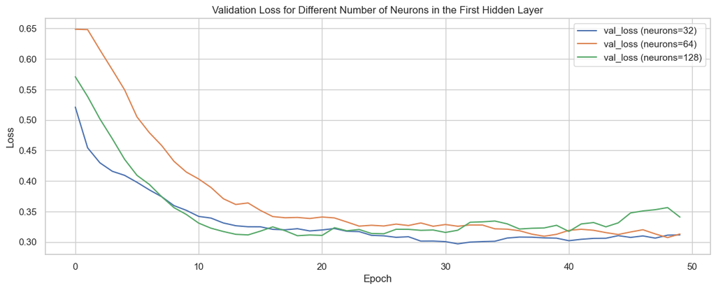

```python
num_neurons_list = [32, 64, 128]
histories = {}

for nn in num_neurons_list:
    model = create_model(num_neurons=nn)
    history = model.fit(X_train, y_train, epochs=50, batch_size=32, validation_data=(X_test, y_test))
    histories[nn] = history

plt.figure(figsize=(14, 5))
for nn, history in histories.items():
    plt.plot(history.history['val_loss'], label=f'val_loss (neurons={nn})')
plt.title('Validation Loss for Different Number of Neurons in the First Hidden Layer')
plt.ylabel('Loss')
plt.xlabel('Epoch')
plt.legend(loc='upper right')
plt.show()
```

First layer with 32 showed the least capacity of the model, while $128$ showed the most capacity to understand complex models.

- Plot 5

Experiment with training for 50, 100, 150, and 200 epochs

```
37/37 ━━━━━━━━━━━━━━━━━━━━ 2s 7ms/step - accuracy: 0.5265 - loss: 0.9704 - val_accuracy: 0.8537 - val_loss: 0.6136
37/37 ━━━━━━━━━━━━━━━━━━━━ 0s 3ms/step - accuracy: 0.5960 - loss: 0.7789 - val_accuracy: 0.8639 - val_loss: 0.5360
37/37 ━━━━━━━━━━━━━━━━━━━━ 0s 3ms/step - accuracy: 0.6234 - loss: 0.7378 - val_accuracy: 0.8673 - val_loss: 0.4833
37/37 ━━━━━━━━━━━━━━━━━━━━ 0s 3ms/step - accuracy: 0.6730 - loss: 0.6325 - val_accuracy: 0.8673 - val_loss: 0.4534
37/37 ━━━━━━━━━━━━━━━━━━━━ 0s 2ms/step - accuracy: 0.7097 - loss: 0.5939 - val_accuracy: 0.8673 - val_loss: 0.4235
37/37 ━━━━━━━━━━━━━━━━━━━━ 0s 3ms/step - accuracy: 0.7685 - loss: 0.5091 - val_accuracy: 0.8741 - val_loss: 0.4030
37/37 ━━━━━━━━━━━━━━━━━━━━ 0s 3ms/step - accuracy: 0.7593 - loss: 0.5102 - val_accuracy: 0.8776 - val_loss: 0.3846
37/37 ━━━━━━━━━━━━━━━━━━━━ 0s 3ms/step - accuracy: 0.7686 - loss: 0.4987 - val_accuracy: 0.8844 - val_loss: 0.3632
37/37 ━━━━━━━━━━━━━━━━━━━━ 0s 3ms/step - accuracy: 0.8113 - loss: 0.4492 - val_accuracy: 0.8912 - val_loss: 0.3475
37/37 ━━━━━━━━━━━━━━━━━━━━ 0s 3ms/step - accuracy: 0.8392 - loss: 0.4084 - val_accuracy: 0.8980 - val_loss: 0.3376
37/37 ━━━━━━━━━━━━━━━━━━━━ 0s 3ms/step - accuracy: 0.8231 - loss: 0.4344 - val_accuracy: 0.8912 - val_loss: 0.3353
37/37 ━━━━━━━━━━━━━━━━━━━━ 0s 3ms/step - accuracy: 0.8413 - loss: 0.3779 - val_accuracy: 0.8946 - val_loss: 0.3302
37/37 ━━━━━━━━━━━━━━━━━━━━ 0s 3ms/step - accuracy: 0.8309 - loss: 0.3825 - val_accuracy: 0.8946 - val_loss: 0.3307
37/37 ━━━━━━━━━━━━━━━━━━━━ 0s 3ms/step - accuracy: 0.8443 - loss: 0.3783 - val_accuracy: 0.8980 - val_loss: 0.3227
37/37 ━━━━━━━━━━━━━━━━━━━━ 0s 3ms/step - accuracy: 0.8488 - loss: 0.3938 - val_accuracy: 0.8912 - val_loss: 0.3135
37/37 ━━━━━━━━━━━━━━━━━━━━ 0s 3ms/step - accuracy: 0.8326 - loss: 0.4036 - val_accuracy: 0.8878 - val_loss: 0.3106
37/37 ━━━━━━━━━━━━━━━━━━━━ 0s 3ms/step - accuracy: 0.8661 - loss: 0.3580 - val_accuracy: 0.8878 - val_loss: 0.3082
37/37 ━━━━━━━━━━━━━━━━━━━━ 0s 3ms/step - accuracy: 0.8635 - loss: 0.3341 - val_accuracy: 0.8912 - val_loss: 0.3053
37/37 ━━━━━━━━━━━━━━━━━━━━ 0s 3ms/step - accuracy: 0.8714 - loss: 0.3314 - val_accuracy: 0.8844 - val_loss: 0.3061
37/37 ━━━━━━━━━━━━━━━━━━━━ 0s 3ms/step - accuracy: 0.8801 - loss: 0.3154 - val_accuracy: 0.8776 - val_loss: 0.3130
37/37 ━━━━━━━━━━━━━━━━━━━━ 0s 3ms/step - accuracy: 0.8693 - loss: 0.3302 - val_accuracy: 0.8844 - val_loss: 0.3088
37/37 ━━━━━━━━━━━━━━━━━━━━ 0s 3ms/step - accuracy: 0.8747 - loss: 0.3360 - val_accuracy: 0.8980 - val_loss: 0.3043
37/37 ━━━━━━━━━━━━━━━━━━━━ 0s 3ms/step - accuracy: 0.8855 - loss: 0.2931 - val_accuracy: 0.8946 - val_loss: 0.3018
37/37 ━━━━━━━━━━━━━━━━━━━━ 0s 3ms/step - accuracy: 0.9104 - loss: 0.2831 - val_accuracy: 0.9014 - val_loss: 0.2955
37/37 ━━━━━━━━━━━━━━━━━━━━ 0s 2ms/step - accuracy: 0.8698 - loss: 0.3079 - val_accuracy: 0.8878 - val_loss: 0.3049
37/37 ━━━━━━━━━━━━━━━━━━━━ 0s 3ms/step - accuracy: 0.8684 - loss: 0.3122 - val_accuracy: 0.8980 - val_loss: 0.2991
37/37 ━━━━━━━━━━━━━━━━━━━━ 0s 3ms/step - accuracy: 0.8788 - loss: 0.3110 - val_accuracy: 0.8776 - val_loss: 0.3085
37/37 ━━━━━━━━━━━━━━━━━━━━ 0s 3ms/step - accuracy: 0.9000 - loss: 0.2827 - val_accuracy: 0.8810 - val_loss: 0.3069
37/37 ━━━━━━━━━━━━━━━━━━━━ 0s 3ms/step - accuracy: 0.8989 - loss: 0.2659 - val_accuracy: 0.8844 - val_loss: 0.3092
37/37 ━━━━━━━━━━━━━━━━━━━━ 0s 3ms/step - accuracy: 0.8982 - loss: 0.2640 - val_accuracy: 0.8810 - val_loss: 0.3138
37/37 ━━━━━━━━━━━━━━━━━━━━ 0s 3ms/step - accuracy: 0.8868 - loss: 0.2675 - val_accuracy: 0.8810 - val_loss: 0.3050
37/37 ━━━━━━━━━━━━━━━━━━━━ 0s 3ms/step - accuracy: 0.9174 - loss: 0.2446 - val_accuracy: 0.8946 - val_loss: 0.3086
37/37 ━━━━━━━━━━━━━━━━━━━━ 0s 3ms/step - accuracy: 0.8905 - loss: 0.2863 - val_accuracy: 0.8980 - val_loss: 0.3115
37/37 ━━━━━━━━━━━━━━━━━━━━ 0s 3ms/step - accuracy: 0.9139 - loss: 0.2218 - val_accuracy: 0.8946 - val_loss: 0.3149
37/37 ━━━━━━━━━━━━━━━━━━━━ 0s 4ms/step - accuracy: 0.9029 - loss: 0.2726 - val_accuracy: 0.8912 - val_loss: 0.3034
37/37 ━━━━━━━━━━━━━━━━━━━━ 0s 3ms/step - accuracy: 0.8913 - loss: 0.2504 - val_accuracy: 0.8844 - val_loss: 0.3154
37/37 ━━━━━━━━━━━━━━━━━━━━ 0s 3ms/step - accuracy: 0.9100 - loss: 0.2326 - val_accuracy: 0.8741 - val_loss: 0.3248
37/37 ━━━━━━━━━━━━━━━━━━━━ 0s 3ms/step - accuracy: 0.9063 - loss: 0.2511 - val_accuracy: 0.8707 - val_loss: 0.3359
37/37 ━━━━━━━━━━━━━━━━━━━━ 0s 3ms/step - accuracy: 0.9121 - loss: 0.2177 - val_accuracy: 0.8878 - val_loss: 0.3200
37/37 ━━━━━━━━━━━━━━━━━━━━ 0s 3ms/step - accuracy: 0.9081 - loss: 0.2199 - val_accuracy: 0.8980 - val_loss: 0.3149
```

[output cut: 445 more lines]

```
37/37 ━━━━━━━━━━━━━━━━━━━━ 0s 3ms/step - accuracy: 0.9808 - loss: 0.0448 - val_accuracy: 0.8605 - val_loss: 0.5953
37/37 ━━━━━━━━━━━━━━━━━━━━ 0s 3ms/step - accuracy: 0.9788 - loss: 0.0603 - val_accuracy: 0.8639 - val_loss: 0.6204
37/37 ━━━━━━━━━━━━━━━━━━━━ 0s 3ms/step - accuracy: 0.9836 - loss: 0.0410 - val_accuracy: 0.8741 - val_loss: 0.6125
37/37 ━━━━━━━━━━━━━━━━━━━━ 0s 2ms/step - accuracy: 0.9842 - loss: 0.0495 - val_accuracy: 0.8776 - val_loss: 0.5889
37/37 ━━━━━━━━━━━━━━━━━━━━ 0s 3ms/step - accuracy: 0.9679 - loss: 0.0705 - val_accuracy: 0.8639 - val_loss: 0.6130
37/37 ━━━━━━━━━━━━━━━━━━━━ 0s 2ms/step - accuracy: 0.9599 - loss: 0.0978 - val_accuracy: 0.8810 - val_loss: 0.5975
37/37 ━━━━━━━━━━━━━━━━━━━━ 0s 3ms/step - accuracy: 0.9708 - loss: 0.0699 - val_accuracy: 0.8707 - val_loss: 0.6383
37/37 ━━━━━━━━━━━━━━━━━━━━ 0s 3ms/step - accuracy: 0.9868 - loss: 0.0405 - val_accuracy: 0.8639 - val_loss: 0.6302
37/37 ━━━━━━━━━━━━━━━━━━━━ 0s 3ms/step - accuracy: 0.9680 - loss: 0.0917 - val_accuracy: 0.8639 - val_loss: 0.6247
37/37 ━━━━━━━━━━━━━━━━━━━━ 0s 3ms/step - accuracy: 0.9876 - loss: 0.0428 - val_accuracy: 0.8503 - val_loss: 0.6420
37/37 ━━━━━━━━━━━━━━━━━━━━ 0s 3ms/step - accuracy: 0.9908 - loss: 0.0353 - val_accuracy: 0.8639 - val_loss: 0.6194
37/37 ━━━━━━━━━━━━━━━━━━━━ 0s 3ms/step - accuracy: 0.9889 - loss: 0.0451 - val_accuracy: 0.8571 - val_loss: 0.6263
37/37 ━━━━━━━━━━━━━━━━━━━━ 0s 3ms/step - accuracy: 0.9939 - loss: 0.0321 - val_accuracy: 0.8605 - val_loss: 0.6616
37/37 ━━━━━━━━━━━━━━━━━━━━ 0s 3ms/step - accuracy: 0.9896 - loss: 0.0345 - val_accuracy: 0.8707 - val_loss: 0.6658
37/37 ━━━━━━━━━━━━━━━━━━━━ 0s 3ms/step - accuracy: 0.9871 - loss: 0.0361 - val_accuracy: 0.8673 - val_loss: 0.6519
```

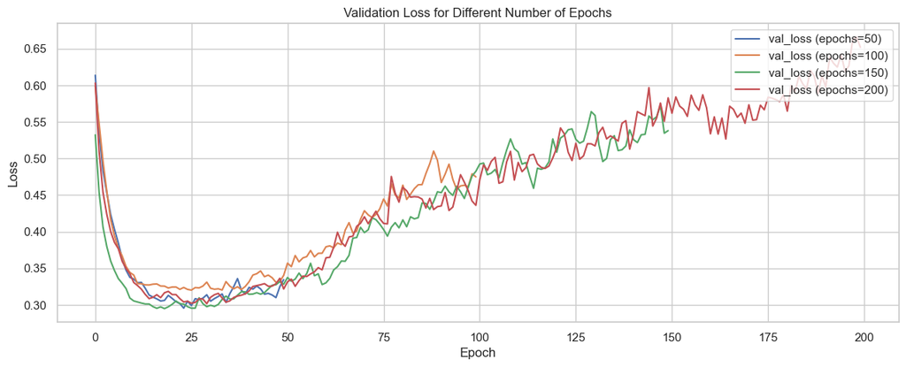

```python
epochs_list = [50, 100, 150, 200]
histories = {}

for epochs in epochs_list:
    model = create_model()
    history = model.fit(X_train, y_train, epochs=epochs, batch_size=32, validation_data=(X_test, y_test))
    histories[epochs] = history

plt.figure(figsize=(14, 5))
for epochs, history in histories.items():
    plt.plot(history.history['val_loss'], label=f'val_loss (epochs={epochs})')
plt.title('Validation Loss for Different Number of Epochs')
plt.ylabel('Loss')
plt.xlabel('Epoch')
plt.legend(loc='upper right')
plt.show()
```

##### We use all the best hyperparameters to make the model.

- Learning Rate: 0.001 (based on optimal convergence)
- Dropout Rate: 0.5 (to prevent overfitting)
- Number of Neurons: 128 in the first hidden layer (to capture complex patterns)
- Epochs: 100 (sufficient for convergence)
- Batch Size: 32 (optimal for training dynamics)

```
Model: "sequential_39"
```

```
┏━━━━━━━━━━━━━━━━━━━━━━━━━━━━━━━━━┳━━━━━━━━━━━━━━━━━━━━━━━━┳━━━━━━━━━━━━━━━┓
┃ Layer (type)                    ┃ Output Shape           ┃       Param # ┃
┡━━━━━━━━━━━━━━━━━━━━━━━━━━━━━━━━━╇━━━━━━━━━━━━━━━━━━━━━━━━╇━━━━━━━━━━━━━━━┩
│ dense_156 (Dense)               │ (None, 128)            │         8,448 │
├─────────────────────────────────┼────────────────────────┼───────────────┤
│ batch_normalization_117         │ (None, 128)            │           512 │
│ (BatchNormalization)            │                        │               │
├─────────────────────────────────┼────────────────────────┼───────────────┤
│ dropout_117 (Dropout)           │ (None, 128)            │             0 │
├─────────────────────────────────┼────────────────────────┼───────────────┤
│ dense_157 (Dense)               │ (None, 64)             │         8,256 │
├─────────────────────────────────┼────────────────────────┼───────────────┤
│ batch_normalization_118         │ (None, 64)             │           256 │
│ (BatchNormalization)            │                        │               │
├─────────────────────────────────┼────────────────────────┼───────────────┤
│ dropout_118 (Dropout)           │ (None, 64)             │             0 │
├─────────────────────────────────┼────────────────────────┼───────────────┤
│ dense_158 (Dense)               │ (None, 32)             │         2,080 │
├─────────────────────────────────┼────────────────────────┼───────────────┤
│ batch_normalization_119         │ (None, 32)             │           128 │
│ (BatchNormalization)            │                        │               │
├─────────────────────────────────┼────────────────────────┼───────────────┤
│ dropout_119 (Dropout)           │ (None, 32)             │             0 │
├─────────────────────────────────┼────────────────────────┼───────────────┤
│ dense_159 (Dense)               │ (None, 1)              │            33 │
└─────────────────────────────────┴────────────────────────┴───────────────┘
```

```
 Total params: 19,713 (77.00 KB)
```

```
 Trainable params: 19,265 (75.25 KB)
```

```
 Non-trainable params: 448 (1.75 KB)
```

```
37/37 ━━━━━━━━━━━━━━━━━━━━ 2s 7ms/step - accuracy: 0.4860 - loss: 1.0489 - val_accuracy: 0.7449 - val_loss: 0.6370
37/37 ━━━━━━━━━━━━━━━━━━━━ 0s 3ms/step - accuracy: 0.5687 - loss: 0.8638 - val_accuracy: 0.7959 - val_loss: 0.6080
37/37 ━━━━━━━━━━━━━━━━━━━━ 0s 3ms/step - accuracy: 0.5949 - loss: 0.7429 - val_accuracy: 0.8265 - val_loss: 0.5755
37/37 ━━━━━━━━━━━━━━━━━━━━ 0s 3ms/step - accuracy: 0.6693 - loss: 0.6234 - val_accuracy: 0.8435 - val_loss: 0.5311
37/37 ━━━━━━━━━━━━━━━━━━━━ 0s 3ms/step - accuracy: 0.7047 - loss: 0.5874 - val_accuracy: 0.8469 - val_loss: 0.5001
37/37 ━━━━━━━━━━━━━━━━━━━━ 0s 3ms/step - accuracy: 0.7235 - loss: 0.5771 - val_accuracy: 0.8503 - val_loss: 0.4750
37/37 ━━━━━━━━━━━━━━━━━━━━ 0s 3ms/step - accuracy: 0.7772 - loss: 0.5353 - val_accuracy: 0.8537 - val_loss: 0.4523
37/37 ━━━━━━━━━━━━━━━━━━━━ 0s 3ms/step - accuracy: 0.7557 - loss: 0.5245 - val_accuracy: 0.8605 - val_loss: 0.4164
37/37 ━━━━━━━━━━━━━━━━━━━━ 0s 3ms/step - accuracy: 0.8087 - loss: 0.4642 - val_accuracy: 0.8673 - val_loss: 0.3948
37/37 ━━━━━━━━━━━━━━━━━━━━ 0s 3ms/step - accuracy: 0.7843 - loss: 0.4669 - val_accuracy: 0.8707 - val_loss: 0.3790
37/37 ━━━━━━━━━━━━━━━━━━━━ 0s 2ms/step - accuracy: 0.7945 - loss: 0.4600 - val_accuracy: 0.8741 - val_loss: 0.3722
37/37 ━━━━━━━━━━━━━━━━━━━━ 0s 3ms/step - accuracy: 0.7915 - loss: 0.4673 - val_accuracy: 0.8776 - val_loss: 0.3595
37/37 ━━━━━━━━━━━━━━━━━━━━ 0s 3ms/step - accuracy: 0.8231 - loss: 0.4441 - val_accuracy: 0.8776 - val_loss: 0.3459
37/37 ━━━━━━━━━━━━━━━━━━━━ 0s 3ms/step - accuracy: 0.8389 - loss: 0.4009 - val_accuracy: 0.8741 - val_loss: 0.3436
37/37 ━━━━━━━━━━━━━━━━━━━━ 0s 3ms/step - accuracy: 0.8291 - loss: 0.4120 - val_accuracy: 0.8707 - val_loss: 0.3372
37/37 ━━━━━━━━━━━━━━━━━━━━ 0s 3ms/step - accuracy: 0.8243 - loss: 0.3981 - val_accuracy: 0.8707 - val_loss: 0.3309
37/37 ━━━━━━━━━━━━━━━━━━━━ 0s 4ms/step - accuracy: 0.8422 - loss: 0.3640 - val_accuracy: 0.8673 - val_loss: 0.3236
37/37 ━━━━━━━━━━━━━━━━━━━━ 0s 4ms/step - accuracy: 0.8526 - loss: 0.3810 - val_accuracy: 0.8844 - val_loss: 0.3240
37/37 ━━━━━━━━━━━━━━━━━━━━ 0s 2ms/step - accuracy: 0.8638 - loss: 0.3444 - val_accuracy: 0.8810 - val_loss: 0.3198
37/37 ━━━━━━━━━━━━━━━━━━━━ 0s 3ms/step - accuracy: 0.8687 - loss: 0.3427 - val_accuracy: 0.8878 - val_loss: 0.3171
37/37 ━━━━━━━━━━━━━━━━━━━━ 0s 3ms/step - accuracy: 0.8655 - loss: 0.3391 - val_accuracy: 0.8844 - val_loss: 0.3186
37/37 ━━━━━━━━━━━━━━━━━━━━ 0s 3ms/step - accuracy: 0.8638 - loss: 0.3499 - val_accuracy: 0.8844 - val_loss: 0.3254
37/37 ━━━━━━━━━━━━━━━━━━━━ 0s 3ms/step - accuracy: 0.8546 - loss: 0.3425 - val_accuracy: 0.8878 - val_loss: 0.3219
37/37 ━━━━━━━━━━━━━━━━━━━━ 0s 3ms/step - accuracy: 0.8579 - loss: 0.3240 - val_accuracy: 0.8810 - val_loss: 0.3237
37/37 ━━━━━━━━━━━━━━━━━━━━ 0s 3ms/step - accuracy: 0.8819 - loss: 0.3173 - val_accuracy: 0.8810 - val_loss: 0.3248
37/37 ━━━━━━━━━━━━━━━━━━━━ 0s 3ms/step - accuracy: 0.8679 - loss: 0.3071 - val_accuracy: 0.8844 - val_loss: 0.3211
37/37 ━━━━━━━━━━━━━━━━━━━━ 0s 3ms/step - accuracy: 0.8890 - loss: 0.3028 - val_accuracy: 0.8844 - val_loss: 0.3126
37/37 ━━━━━━━━━━━━━━━━━━━━ 0s 3ms/step - accuracy: 0.8896 - loss: 0.2836 - val_accuracy: 0.8912 - val_loss: 0.3082
37/37 ━━━━━━━━━━━━━━━━━━━━ 0s 3ms/step - accuracy: 0.8670 - loss: 0.3195 - val_accuracy: 0.8946 - val_loss: 0.3110
37/37 ━━━━━━━━━━━━━━━━━━━━ 0s 3ms/step - accuracy: 0.8999 - loss: 0.2659 - val_accuracy: 0.8912 - val_loss: 0.3166
37/37 ━━━━━━━━━━━━━━━━━━━━ 0s 3ms/step - accuracy: 0.9086 - loss: 0.2585 - val_accuracy: 0.8878 - val_loss: 0.3135
37/37 ━━━━━━━━━━━━━━━━━━━━ 0s 3ms/step - accuracy: 0.8775 - loss: 0.2956 - val_accuracy: 0.8844 - val_loss: 0.3086
37/37 ━━━━━━━━━━━━━━━━━━━━ 0s 3ms/step - accuracy: 0.8734 - loss: 0.2732 - val_accuracy: 0.8673 - val_loss: 0.3224
37/37 ━━━━━━━━━━━━━━━━━━━━ 0s 3ms/step - accuracy: 0.8830 - loss: 0.2977 - val_accuracy: 0.8878 - val_loss: 0.3162
37/37 ━━━━━━━━━━━━━━━━━━━━ 0s 3ms/step - accuracy: 0.8833 - loss: 0.2868 - val_accuracy: 0.8776 - val_loss: 0.3195
37/37 ━━━━━━━━━━━━━━━━━━━━ 0s 2ms/step - accuracy: 0.8951 - loss: 0.2690 - val_accuracy: 0.8776 - val_loss: 0.3262
37/37 ━━━━━━━━━━━━━━━━━━━━ 0s 3ms/step - accuracy: 0.8982 - loss: 0.2544 - val_accuracy: 0.8741 - val_loss: 0.3280
37/37 ━━━━━━━━━━━━━━━━━━━━ 0s 3ms/step - accuracy: 0.9112 - loss: 0.2364 - val_accuracy: 0.8707 - val_loss: 0.3399
37/37 ━━━━━━━━━━━━━━━━━━━━ 0s 3ms/step - accuracy: 0.8919 - loss: 0.2417 - val_accuracy: 0.8639 - val_loss: 0.3475
37/37 ━━━━━━━━━━━━━━━━━━━━ 0s 3ms/step - accuracy: 0.8972 - loss: 0.2537 - val_accuracy: 0.8639 - val_loss: 0.3370
```

[output cut: 45 more lines]

```
37/37 ━━━━━━━━━━━━━━━━━━━━ 0s 3ms/step - accuracy: 0.9359 - loss: 0.1492 - val_accuracy: 0.8844 - val_loss: 0.4690
37/37 ━━━━━━━━━━━━━━━━━━━━ 0s 3ms/step - accuracy: 0.9632 - loss: 0.0991 - val_accuracy: 0.8776 - val_loss: 0.4841
37/37 ━━━━━━━━━━━━━━━━━━━━ 0s 2ms/step - accuracy: 0.9579 - loss: 0.1227 - val_accuracy: 0.8639 - val_loss: 0.5012
37/37 ━━━━━━━━━━━━━━━━━━━━ 0s 3ms/step - accuracy: 0.9517 - loss: 0.1246 - val_accuracy: 0.8639 - val_loss: 0.4650
37/37 ━━━━━━━━━━━━━━━━━━━━ 0s 2ms/step - accuracy: 0.9455 - loss: 0.1468 - val_accuracy: 0.8673 - val_loss: 0.4601
37/37 ━━━━━━━━━━━━━━━━━━━━ 0s 3ms/step - accuracy: 0.9709 - loss: 0.0922 - val_accuracy: 0.8707 - val_loss: 0.4801
37/37 ━━━━━━━━━━━━━━━━━━━━ 0s 3ms/step - accuracy: 0.9620 - loss: 0.1068 - val_accuracy: 0.8741 - val_loss: 0.4637
37/37 ━━━━━━━━━━━━━━━━━━━━ 0s 2ms/step - accuracy: 0.9663 - loss: 0.0917 - val_accuracy: 0.8673 - val_loss: 0.4934
37/37 ━━━━━━━━━━━━━━━━━━━━ 0s 3ms/step - accuracy: 0.9470 - loss: 0.1154 - val_accuracy: 0.8878 - val_loss: 0.4850
37/37 ━━━━━━━━━━━━━━━━━━━━ 0s 3ms/step - accuracy: 0.9695 - loss: 0.0901 - val_accuracy: 0.8810 - val_loss: 0.4835
37/37 ━━━━━━━━━━━━━━━━━━━━ 0s 3ms/step - accuracy: 0.9712 - loss: 0.0794 - val_accuracy: 0.8844 - val_loss: 0.4600
37/37 ━━━━━━━━━━━━━━━━━━━━ 0s 3ms/step - accuracy: 0.9672 - loss: 0.0940 - val_accuracy: 0.8810 - val_loss: 0.4679
37/37 ━━━━━━━━━━━━━━━━━━━━ 0s 3ms/step - accuracy: 0.9618 - loss: 0.0932 - val_accuracy: 0.8707 - val_loss: 0.4691
37/37 ━━━━━━━━━━━━━━━━━━━━ 0s 3ms/step - accuracy: 0.9645 - loss: 0.0970 - val_accuracy: 0.8707 - val_loss: 0.5025
37/37 ━━━━━━━━━━━━━━━━━━━━ 0s 3ms/step - accuracy: 0.9515 - loss: 0.1057 - val_accuracy: 0.8741 - val_loss: 0.5003
```

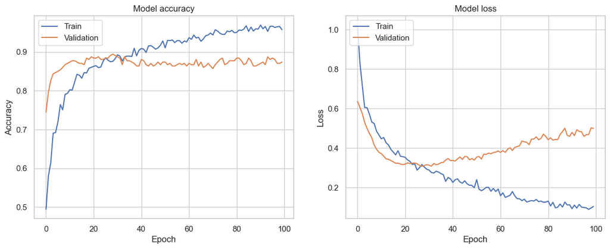

```python
# Import necessary libraries
import numpy as np
import pandas as pd
from sklearn.model_selection import train_test_split
from tensorflow.keras.models import Sequential
from tensorflow.keras.layers import Dense, Dropout, BatchNormalization
from tensorflow.keras.optimizers import Adam
import matplotlib.pyplot as plt

X_train, X_test, y_train, y_test = train_test_split(data_NN, y, test_size=0.2, random_state=42)

# Define a function to create the model
def create_model(learning_rate=0.001, dropout_rate=0.5, num_neurons=128):
    model = Sequential()
    # Input layer and first hidden layer
    model.add(Dense(num_neurons, input_shape=(X_train.shape[1],), activation='relu'))
    model.add(BatchNormalization())
    model.add(Dropout(0.4))

    # First hidden layer
    model.add(Dense(64, activation='relu'))
    model.add(BatchNormalization())
    model.add(Dropout(dropout_rate))

    # Second hidden layer
    model.add(Dense(32, activation='relu'))
    model.add(BatchNormalization())
    model.add(Dropout(dropout_rate))

    # Output layer
    model.add(Dense(1, activation='sigmoid'))

    # Compile the model
    model.compile(optimizer=Adam(learning_rate=learning_rate), loss='binary_crossentropy', metrics=['accuracy'])
    return model

# Create the final model
final_model = create_model(learning_rate=0.001, dropout_rate=0.5, num_neurons=128)

# Model summary
final_model.summary()

# Train the model
history = final_model.fit(X_train, y_train, epochs=100, batch_size=32, validation_data=(X_test, y_test))

# Plot training & validation accuracy values
plt.figure(figsize=(14, 5))

plt.subplot(1, 2, 1)
plt.plot(history.history['accuracy'])
plt.plot(history.history['val_accuracy'])
plt.title('Model accuracy')
plt.ylabel('Accuracy')
plt.xlabel('Epoch')
plt.legend(['Train', 'Validation'], loc='upper left')

# Plot training & validation loss values
plt.subplot(1, 2, 2)
plt.plot(history.history['loss'])
plt.plot(history.history['val_loss'])
plt.title('Model loss')
plt.ylabel('Loss')
plt.xlabel('Epoch')
plt.legend(['Train', 'Validation'], loc='upper left')

plt.show()
```

### Final model using all the best hyperparameters

# Model Comparison

In Machine Learning, Model Comparison stands as a pivotal step, aiming to identify the optimal model for our requirements and assess its performance upon deployment. Two key considerations in this evaluation process are how the data is partitioned and which metric is employed for assessment.

In our approach, we utilized a 5-Fold Cross-Validation technique across all algorithms. As for the evaluation metric, we selected roc_auc due to the nature of our classification problem, the binary target feature, and the presence of class imbalance. This metric aligns well with the characteristics of our problem.

Finally, we calculated the mean cross_val_score for each classifier using their respective best estimators. This comprehensive approach allows us to make informed decisions about the most suitable model for our predictive task.

```python
# Importing necessary packages
from sklearn.model_selection import cross_val_score, RepeatedStratifiedKFold

cv_method_t_test = RepeatedStratifiedKFold(n_splits=5, n_repeats = 1, random_state=99)

cv_results_KNN = cross_val_score(estimator=gs_pipe_KNN.best_estimator_,
                                 X=X_test,
                                 y=y_test,
                                 cv=cv_method_t_test,
                                 n_jobs=-1,
                                 scoring='roc_auc')
# Obtaining the mean roc_auc score
cv_results_KNN.mean()
```

```
0.7092086834733894
```

```python
# Performing for Decision Tree
cv_results_DT = cross_val_score(estimator=gs_pipe_dt.best_estimator_,
                                 X=X_test,
                                 y=y_test,
                                 cv=cv_method_t_test,
                                 n_jobs=-2,
                                 scoring='roc_auc')

# Obtaining the mean roc_auc score
cv_results_DT.mean()
```

```
0.6280812324929973
```

```python
# Performing for Naive Bayes

# Power Transforming the descriptive test data-set
d_test_transformed = PowerTransformer().fit_transform(X_test)

cv_results_NB = cross_val_score(estimator=gs_pipe_NB.best_estimator_,
                                 X=X_test,
                                 y=y_test,
                                 cv=cv_method_t_test,
                                 n_jobs=-2,
                                 scoring='roc_auc')

# Obtaining the mean roc_auc score
cv_results_NB.mean()
```

```
0.6898459383753501
```

```python
# Performing for Logistic Regressor
cv_results_LR = cross_val_score(estimator=gs_pipe_LR.best_estimator_,
                                 X=X_test,
                                 y=y_test,
                                 cv=cv_method_t_test,
                                 n_jobs=-2,
                                 scoring='roc_auc')

# Obtaining the mean roc_auc score
cv_results_LR.mean()
```

```
0.732703081232493
```

```python
# Performing for Random Forest
cv_results_rf = cross_val_score(estimator=gs_pipe_rf.best_estimator_,
                                 X=X_test,
                                 y=y_test,
                                 cv=cv_method_t_test,
                                 n_jobs=-2,
                                 scoring='roc_auc')

# Obtaining the mean roc_auc score
cv_results_rf.mean()
```

```
0.7105042016806722
```

Given these close scores, it is necessary to conduct a statistical test to determine if the differences are statistically significant. This will help us decide whether we can reject our null hypothesis.

```python
from scipy import stats
import pandas as pd

# Conducting the t-tests
ttest_results = {
    'Comparison': ['KNN v. DT', 'KNN v. NB', 'KNN v. LR', 'DT v. NB', 'DT v. LR', 'NB v. LR'],
    'T-statistic': [
        stats.ttest_rel(cv_results_KNN, cv_results_DT).statistic,
        stats.ttest_rel(cv_results_KNN, cv_results_NB).statistic,
        stats.ttest_rel(cv_results_KNN, cv_results_LR).statistic,
        stats.ttest_rel(cv_results_DT, cv_results_NB).statistic,
        stats.ttest_rel(cv_results_DT, cv_results_LR).statistic,
        stats.ttest_rel(cv_results_NB, cv_results_LR).statistic
    ],
    'P-value': [
        stats.ttest_rel(cv_results_KNN, cv_results_DT).pvalue,
        stats.ttest_rel(cv_results_KNN, cv_results_NB).pvalue,
        stats.ttest_rel(cv_results_KNN, cv_results_LR).pvalue,
        stats.ttest_rel(cv_results_DT, cv_results_NB).pvalue,
        stats.ttest_rel(cv_results_DT, cv_results_LR).pvalue,
        stats.ttest_rel(cv_results_NB, cv_results_LR).pvalue
    ]
}

# Creating a DataFrame for better visualization
ttest_df = pd.DataFrame(ttest_results)

# Display the DataFrame
ttest_df
```

|  | Comparison | T-statistic | P-value |
| --- | --- | --- | --- |
| 0 | KNN v. DT | 1.981432 | 0.118607 |
| 1 | KNN v. NB | 1.555010 | 0.194919 |
| 2 | KNN v. LR | -1.084622 | 0.339089 |
| 3 | DT v. NB | -1.945873 | 0.123541 |
| 4 | DT v. LR | -2.780526 | 0.049792 |
| 5 | NB v. LR | -3.307432 | 0.029726 |

The p-value is crucial in our analysis. If it is greater than the significance level of `0.05`, we consider the test results to be statistically insignificant. From the previous results, we observe that only two out of the six comparisons have a p-value less than 0.05: DT vs. LR and NB vs. LR.

Therefore, we conclude that the Logistic Regressor is the best model, as it statistically outperforms both the Decision Tree and Naive Bayes. However, it does not show a statistically significant difference when compared with K-Nearest Neighbors.

# Critique & Limitations

During preprocessing, we deliberately excluded the 'StandardHours' attribute from our analysis, as our primary goal was to predict outcomes without relying on the working hours of an employee. However, it's worth noting that some analysts might consider this attribute due to its significant influence on the target feature.

An advantage of our models is their ability to mitigate overfitting by selecting a subset of features. Although some degree of overfitting may still occur, it's significantly reduced compared to models using the complete feature set.

During hyperparameter tuning of our neural network model, we encountered an issue where computing roc_auc resulted in nan values. Consequently, we used accuracy as an alternative metric. If the model could track roc_auc loss during runtime, we could have compared its performance more effectively with other models.

Based on statistical tests and classification matrices, we identified the Logistic Regressor as the optimal model for our dataset. To further enhance its performance, additional hyperparameters such as 'max_iter' and 'class_weight' could be considered.

Consistently, the Naive Bayes model exhibited the second lowest performance scores on training data, test data (without cross-validation), and roc_auc scores for ROC Curve plotting. This may be attributed to the power transformation applied, and the confusion matrix revealed evident issues with the 'zero frequency problem' for this dataset.

Since the Decision Tree emerged as the least best model, a potential enhancement could involve fitting an ensemble model like the Random Forest Classifier, which might improve recall percentages.

At last, the limitation in our analysis arises from the statistical tests, where the p-value comparison showed that Logistic Regression was not significantly better than KNN (p = 0.339089). This suggests that the difference in performance between Logistic Regression and KNN may not be substantial enough to confidently claim superiority.

# Summary & Conclusions

## Project Summary

#### Phase 1

- We examined the data first for any inconsistencies. We removed some features with single unique values, feautures with columns that were not relavant to the task. We looked for any outliers in the data and missing values and did the required cleaning for them.
- We generated data visualizations to check the nature of the data, some trends observed were males having higher attrition rate than females, with employees from reseach department to stay more likely compared to the other departments.

#### Phase 2

- We started this part by feature selection, which we did using random forest and F- scores techniques, which helped us identify the most important or relavant features eg. 𝐴𝑔𝑒, 𝑂𝑣𝑒𝑟𝑡𝑖𝑚𝑒 etc
- After we split the data into training and testing sets (70 and 30 percent respectively). Using ML techniques like decision tree, KNN, Random forest, Naive Bayes, and Logistic Regression, we performed 5 fold stratified cross validation for hyperparameter testing.
- Neural Networks models were built using TensorFlow Keras. We fine tuned hyperparameters to check how the model performed under various constraints.
- At the end we did performance evaluation and compared the performance of the model.

## Summary of Findings

- K-Nearest Neighbor (KNN) = 0.666
- Decision Tree = 0.745
- Naive Bayes = 0.785
- Logistic Regression = 0.840
- Random Forest = 0.810

The Logistic Regression model performed the best on the training data. To prevent overfitting, we re-ran the models that initially selected all features, excluding some to refine the selection process.

# Conclusions

For this project, our main goal was to predict employee turnover and performance using various data features. We used an employee dataset from Kaggle and completed two main phases.

In Phase 1, we focused on cleaning up the data, preparing it for analysis, and creating visualizations. This initial work gave us useful insights into the employee demographics, differences across departments, and factors that seemed to impact employee attrition rates.

Phase 2 involved building predictive models to better understand and forecast employee attrition. We started by selecting the most significant features like age and years of service. Then we tried out several machine learning techniques like K-Nearest Neighbors, Decision Trees, Naive Bayes, and Logistic Regression models.

After careful model training and tuning, the Logistic Regression model emerged as the top performer. Its simplicity, interpretability, and high prediction accuracy made it the preferred model for forecasting employee turnover. We also found that a tuned neural network showed promising accuracy, highlighting its potential as an alternative predictive tool.

In summary, this project provided actionable insights into predicting employee attrition, giving organizations valuable strategies to improve retention and workforce management. By applying advanced machine learning and rigorous analysis, we've equipped stakeholders with powerful tools to make informed decisions and proactively address employee turnover risks for organizational success.

## References

1.GeeksforGeeks. (2022). Predictive Modelling in Python using Matplotlib.

2.Akman D., Feature Ranking. (2022). SK Part 2: Feature Selection and Ranking. https://www.featureranking.com/tutorials/machine-learning-tutorials/sk-part-2-feature-selection-and-ranking/

3.Scikit-Learn. (2022). Logistic Regression.https://scikit-learn.org/stable/modules/generated/sklearn.linear_model.LogisticRegression.html

4.Akman D., Feature Ranking. (2022). SK Part 2: Feature Selection and Ranking. https://www.featureranking.com/tutorials/machine-learning-tutorials/sk-part-2-feature-selection-and-ranking/

5.Chuang, C. H., & Liao, H. (2010). Strategic human resource management in service context: Taking care of business by taking care of employees and customers. Personnel Psychology, 63(1), 153-196.

6.Griffeth, R. W., Hom, P. W., & Gaertner, S. (2000). A meta-analysis of antecedents and correlates of employee turnover: Update, moderator tests, and research implications for the next millennium. Journal of Management, 26(3), 463-488.

7.Hom, P. W., & Kinicki, A. J. (2001). Toward a greater understanding of how dissatisfaction drives employee turnover. Academy of Management Journal, 44(5), 975-987.